# Ibukun Abraham chocolate bars Assignment(GRP9)

### Ibukunoluwa Abraham

WTF/23/DS/B/079

GROUP 9

```python
import pandas as pd
import numpy as np
import matplotlib.pyplot as plt
%matplotlib inline
import seaborn as sns

pd.set_option('display.max_columns',20)
pd.set_option('expand_frame_repr',True)
```

```python
###To read file
choco_bars = pd.read_csv('chocolate_bars.csv',index_col='id')
choco_bars
```

| id | manufacturer | company_location | year_reviewed | bean_origin | bar_name | cocoa_percent | num_ingredients | ingredients | review | rating |
| --- | --- | --- | --- | --- | --- | --- | --- | --- | --- | --- |
| 2454 | 5150 | U.S.A. | 2019 | Tanzania | Kokoa Kamili, batch 1 | 76.0 | 3.0 | B,S,C | rich cocoa, fatty, bready | 3.25 |
| 2458 | 5150 | U.S.A. | 2019 | Dominican Republic | Zorzal, batch 1 | 76.0 | 3.0 | B,S,C | cocoa, vegetal, savory | 3.50 |
| 2454 | 5150 | U.S.A. | 2019 | Madagascar | Bejofo Estate, batch 1 | 76.0 | 3.0 | B,S,C | cocoa, blackberry, full body | 3.75 |
| 2542 | 5150 | U.S.A. | 2021 | Fiji | Matasawalevu, batch 1 | 68.0 | 3.0 | B,S,C | chewy, off, rubbery | 3.00 |
| 2546 | 5150 | U.S.A. | 2021 | Venezuela | Sur del Lago, batch 1 | 72.0 | 3.0 | B,S,C | fatty, earthy, moss, nutty,chalky | 3.00 |
| 2546 | 5150 | U.S.A. | 2021 | Uganda | Semuliki Forest, batch 1 | 80.0 | 3.0 | B,S,C | mildly bitter, basic cocoa, fatty | 3.25 |
| 2542 | 5150 | U.S.A. | 2021 | India | Anamalai, batch 1 | 68.0 | 3.0 | B,S,C | milk brownie, macadamia,chewy | 3.50 |
| 797 | A. Morin | France | 2012 | Bolivia | Bolivia | 70.0 | 4.0 | B,S,C,L | vegetal, nutty | 3.50 |
| 797 | A. Morin | France | 2012 | Peru | Peru | 63.0 | 4.0 | B,S,C,L | fruity, melon, roasty | 3.75 |
| 1011 | A. Morin | France | 2013 | Panama | Panama | 70.0 | 4.0 | B,S,C,L | brief fruit note, earthy, nutty | 2.75 |
| 1015 | A. Morin | France | 2013 | Colombia | Colombie | 70.0 | 4.0 | B,S,C,L | burnt rubber,alkalyzed notes | 2.75 |
| 1011 | A. Morin | France | 2013 | Madagascar | Madagascar, Criollo | 70.0 | 4.0 | B,S,C,L | sticky, red fruit, sour | 3.00 |
| 1015 | A. Morin | France | 2013 | Burma | Birmanie | 70.0 | 4.0 | B,S,C,L | sticky, smokey, grass | 3.00 |
| 1011 | A. Morin | France | 2013 | Brazil | Brazil | 70.0 | 4.0 | B,S,C,L | mild tobacco | 3.25 |
| 1015 | A. Morin | France | 2013 | Papua New Guinea | Papua New Guinea | 70.0 | 4.0 | B,S,C,L | mild fruit, strong smoke | 3.25 |
| 1019 | A. Morin | France | 2013 | Peru | Piura | 70.0 | 4.0 | B,S,C,L | green, nutty, cocoa | 3.25 |
| 1019 | A. Morin | France | 2013 | Peru | Chanchamayo Province | 70.0 | 4.0 | B,S,C,L | cocoa,sour,intense tangerine | 3.50 |
| 1011 | A. Morin | France | 2013 | Ecuador | Equateur | 70.0 | 4.0 | B,S,C,L | sandy, nutty, cocoa, fig | 3.75 |
| 1015 | A. Morin | France | 2013 | Venezuela | Chuao | 70.0 | 4.0 | B,S,C,L | oily, nut, caramel, raspberry | 4.00 |
| 1019 | A. Morin | France | 2013 | Peru | Chanchamayo Province | 63.0 | 3.0 | B,S,C | sweet, cocoa, tangerine | 4.00 |
| 1315 | A. Morin | France | 2014 | Venezuela | Carenero, Criollo | 70.0 | 4.0 | B,S,C,L | harsh, leather, earthy | 2.75 |
| 1315 | A. Morin | France | 2014 | Cuba | Cuba | 70.0 | 4.0 | B,S,C,L | sliglty dry, papaya | 3.50 |
| 1315 | A. Morin | France | 2014 | Venezuela | Sur del Lago, Criollo | 70.0 | 4.0 | B,S,C,L | nutty, mild choco, roasty | 3.50 |
| 1319 | A. Morin | France | 2014 | Venezuela | Puerto Cabello, Criollo | 70.0 | 4.0 | B,S,C,L | astringent, nutty, chocolatey | 3.75 |
| 1319 | A. Morin | France | 2014 | Peru | Pablino | 70.0 | 4.0 | B,S,C,L | delicate, hazelnut, brownie | 4.00 |
| 1676 | A. Morin | France | 2015 | Togo | Kpime | 70.0 | 4.0 | B,S,C,L | burnt wood, earthy, choco | 2.75 |
| 1676 | A. Morin | France | 2015 | Togo | Atsane | 70.0 | 4.0 | B,S,C,L | roasty, acidic, nutty | 3.00 |
| 1680 | A. Morin | France | 2015 | Togo | Akata | 70.0 | 4.0 | B,S,C,L | mild profile, chocolaty, spice | 3.50 |
| 1704 | A. Morin | France | 2015 | Peru | Quilla | 70.0 | 4.0 | B,S,C,L | grainy texture, cocoa, sweet | 3.50 |
| 1876 | A. Morin | France | 2016 | Sao Tome | Agua Grande | 63.0 | 4.0 | B,S,C,L | sweet, chocolatey, vegetal | 3.75 |
| ... | ... | ... | ... | ... | ... | ... | ... | ... | ... | ... |
| 697 | Zokoko | Australia | 2011 | Bolivia | Alto Beni | 68.0 | 4.0 | B,S,C,L | oily, honey, light rum | 3.50 |
| 701 | Zokoko | Australia | 2011 | Papua New Guinea | Tokiala | 66.0 | 4.0 | B,S,C,L | toffee, caramel, butterscotch | 3.50 |
| 701 | Zokoko | Australia | 2011 | Bolivia | Tranquilidad, Baures | 72.0 | 4.0 | B,S,C,L | intense prune and berry | 3.75 |
| 1780 | Zokoko | Australia | 2016 | Blend | Goddess Blend | 65.0 | 5.0 | B,S,C,V,L | oily, sweet, choco, nutty | 3.25 |
| 1716 | Zokoko | Australia | 2016 | Solomon Islands | Guadalcanal | 78.0 | 4.0 | B,S,C,L | smokey, dried fruit, balanced | 3.75 |
| 2044 | Zoto (Chocolatoa) | Belgium | 2018 | Nicaragua | Jeru Antiguo, batch jan705, 2 turns | 72.0 | 3.0 | B,S,C | intense earthy | 3.00 |
| 2230 | Zoto (Chocolatoa) | Belgium | 2018 | DR Congo | Kilimamwenza, Ituri Province | 68.0 | 3.0 | B,S*,C | fatty, herbal, earthy | 3.00 |
| 2064 | Zoto (Chocolatoa) | Belgium | 2018 | Nicaragua | Rugoso | 75.0 | 3.0 | B,S,C | sandy, basic cocoa | 3.25 |
| 2048 | Zoto (Chocolatoa) | Belgium | 2018 | Nicaragua | El Castillero, batch ca1705, 3 turns | 70.0 | 3.0 | B,S,C | large grits, sweet, dried fruit | 3.75 |
| 486 | Zotter | Austria | 2010 | Brazil | Brazil, Mitzi Blue | 65.0 | 4.0 | B,S*,C,Sa | woody, butterscotch | 3.00 |
| 749 | Zotter | Austria | 2011 | Congo | Congo | 65.0 | 4.0 | B,S*,C,Sa | dairy, salt, caramel | 3.00 |
| 781 | Zotter | Austria | 2011 | India | Kerala State | 62.0 | 4.0 | B,S*,C,Sa | oily, subdued, caramel, salt | 3.25 |
| 749 | Zotter | Austria | 2011 | India | Kerala State | 65.0 | 4.0 | B,S*,C,Sa | creamy, masculine, earthy | 3.50 |
| 647 | Zotter | Austria | 2011 | Peru | Peru | 70.0 | 4.0 | B,S*,C,Sa | creamy, fatty, mild nutty | 3.75 |
| 875 | Zotter | Austria | 2012 | Peru | Satipo Pangoa region, 16hr conche | 70.0 | 4.0 | B,S*,C,Sa | woody, toast, pepper | 3.00 |
| 879 | Zotter | Austria | 2012 | Ecuador | El Oro | 75.0 | 4.0 | B,S*,C,Sa | creamy, nutty, bready | 3.00 |
| 879 | Zotter | Austria | 2012 | Papua New Guinea | Huiwani Coop | 75.0 | 4.0 | B,S*,C,Sa | hint of smoke, fruit | 3.00 |
| 879 | Zotter | Austria | 2012 | Bolivia | El Ceibo Coop | 90.0 | 4.0 | B,S*,C,Sa | smooth, intense blueberry | 3.25 |
| 883 | Zotter | Austria | 2012 | Congo | Kongo, Highlands | 68.0 | 4.0 | B,S*,C,Sa | creamy, caramel, salt, sweet | 3.25 |
| 801 | Zotter | Austria | 2012 | Panama | Bocas del Toro, Cocabo Co-op | 72.0 | 4.0 | B,S*,C,Sa | oily, earthy, caramel, salty | 3.50 |
| 801 | Zotter | Austria | 2012 | Blend | Amazonas Frucht | 65.0 | 4.0 | B,S*,C,Sa | dairy, burnt caramel, coffee | 3.50 |
| 875 | Zotter | Austria | 2012 | Peru | Satipo Pangoa region, 20hr conche | 70.0 | 4.0 | B,S*,C,Sa | butterscotch, pepper | 3.50 |
| 883 | Zotter | Austria | 2012 | Blend | Indianer, Raw | 58.0 | 4.0 | B,S*,C,Sa | smooth, spicy, floral | 3.50 |
| 875 | Zotter | Austria | 2012 | Dominican Republic | Loma Los Pinos, Yacao region, D.R. | 62.0 | 4.0 | B,S*,C,Sa | spice, caramel, toffee, salty | 3.75 |
| 879 | Zotter | Austria | 2012 | Dominican Republic | Santo Domingo | 70.0 | 4.0 | B,S*,C,Sa | strawberry, Cadbury egg | 3.75 |
| 1205 | Zotter | Austria | 2014 | Blend | Raw | 80.0 | 4.0 | B,S*,C,Sa | waxy, cloying, vegetal | 2.75 |
| 1996 | Zotter | Austria | 2017 | Colombia | APROCAFA, Acandi | 75.0 | 3.0 | B,S,C | strong nutty, marshmallow | 3.75 |
| 2036 | Zotter | Austria | 2018 | Blend | Dry Aged, 30 yr Anniversary bar | 75.0 | 3.0 | B,S,C | fatty, earthy, cocoa | 3.00 |
| 2170 | Zotter | Austria | 2018 | Congo | Mountains of the Moon | 70.0 | 3.0 | B,S,C | fatty, mild nuts, mild fruit | 3.25 |
| 2170 | Zotter | Austria | 2018 | Belize | Maya Mtn | 72.0 | 3.0 | B,S,C | muted, roasty, accessible | 3.50 |

2530 rows × 10 columns

### DATA DESCRIBING

```python
choco_bars.head() #To view the first five data set
```

| id | manufacturer | company_location | year_reviewed | bean_origin | bar_name | cocoa_percent | num_ingredients | ingredients | review | rating |
| --- | --- | --- | --- | --- | --- | --- | --- | --- | --- | --- |
| 2454 | 5150 | U.S.A. | 2019 | Tanzania | Kokoa Kamili, batch 1 | 76.0 | 3.0 | B,S,C | rich cocoa, fatty, bready | 3.25 |
| 2458 | 5150 | U.S.A. | 2019 | Dominican Republic | Zorzal, batch 1 | 76.0 | 3.0 | B,S,C | cocoa, vegetal, savory | 3.50 |
| 2454 | 5150 | U.S.A. | 2019 | Madagascar | Bejofo Estate, batch 1 | 76.0 | 3.0 | B,S,C | cocoa, blackberry, full body | 3.75 |
| 2542 | 5150 | U.S.A. | 2021 | Fiji | Matasawalevu, batch 1 | 68.0 | 3.0 | B,S,C | chewy, off, rubbery | 3.00 |
| 2546 | 5150 | U.S.A. | 2021 | Venezuela | Sur del Lago, batch 1 | 72.0 | 3.0 | B,S,C | fatty, earthy, moss, nutty,chalky | 3.00 |

```python
choco_bars.tail() #To view the last five data set
```

| id | manufacturer | company_location | year_reviewed | bean_origin | bar_name | cocoa_percent | num_ingredients | ingredients | review | rating |
| --- | --- | --- | --- | --- | --- | --- | --- | --- | --- | --- |
| 1205 | Zotter | Austria | 2014 | Blend | Raw | 80.0 | 4.0 | B,S*,C,Sa | waxy, cloying, vegetal | 2.75 |
| 1996 | Zotter | Austria | 2017 | Colombia | APROCAFA, Acandi | 75.0 | 3.0 | B,S,C | strong nutty, marshmallow | 3.75 |
| 2036 | Zotter | Austria | 2018 | Blend | Dry Aged, 30 yr Anniversary bar | 75.0 | 3.0 | B,S,C | fatty, earthy, cocoa | 3.00 |
| 2170 | Zotter | Austria | 2018 | Congo | Mountains of the Moon | 70.0 | 3.0 | B,S,C | fatty, mild nuts, mild fruit | 3.25 |
| 2170 | Zotter | Austria | 2018 | Belize | Maya Mtn | 72.0 | 3.0 | B,S,C | muted, roasty, accessible | 3.50 |

```python
choco_bars.sample(10) #To randomly view TEN data set
```

| id | manufacturer | company_location | year_reviewed | bean_origin | bar_name | cocoa_percent | num_ingredients | ingredients | review | rating |
| --- | --- | --- | --- | --- | --- | --- | --- | --- | --- | --- |
| 2630 | CAR Artisan | U.S.A. | 2021 | Mexico | Soconusco, batch 2 | 70.0 | 3.0 | B,S,C | strong tobacco, grassy | 3.25 |
| 1672 | Domori | Italy | 2015 | Venezuela | Ocumare 77 | 70.0 | 2.0 | B,S | nutty, strawberry, creamy | 3.75 |
| 552 | Machu Picchu Trading Co. | Peru | 2010 | Peru | Peru | 55.0 | NaN | NaN | extremely sweet, vanilla | 2.25 |
| 1876 | Nugali | Brazil | 2016 | Brazil | Fazenda Leolinda | 70.0 | 3.0 | B,S,C | nutty, banana, cocoa | 3.50 |
| 999 | Bahen & Co. | Australia | 2012 | Blend | Houseblend | 70.0 | 2.0 | B,S | chalky, fragrant, then off | 2.50 |
| 2366 | Shane Chocolate Works | U.S.A. | 2019 | Belize | Belize | 70.0 | 3.0 | B,S,C | full cocoa flavor | 3.50 |
| 2386 | Dandelion | U.S.A. | 2019 | Vietnam | Ben Tre, 2018 Harvest | 70.0 | 2.0 | B,S | green apple, sticky | 3.50 |
| 1478 | Map Chocolate | U.S.A. | 2015 | Ecuador | Ecuador | 70.0 | 3.0 | B,S,C | coarse, floral, rum | 3.50 |
| 2214 | Kad Kokoa | Thailand | 2018 | Thailand | Chantaburi | 70.0 | 3.0 | B,S,C | nutty, cocoa, sour veggie | 3.50 |
| 793 | Spagnvola | U.S.A. | 2012 | Dominican Republic | AgroCriso Plantation | 75.0 | 4.0 | B,S,C,V | oily, floral | 3.25 |

```python
choco_bars.info() ###To get an overview of the dataset
```

```
<class 'pandas.core.frame.DataFrame'>
Int64Index: 2530 entries, 2454 to 2170
Data columns (total 10 columns):
manufacturer        2530 non-null object
company_location    2530 non-null object
year_reviewed       2530 non-null int64
bean_origin         2530 non-null object
bar_name            2530 non-null object
cocoa_percent       2530 non-null float64
num_ingredients     2443 non-null float64
ingredients         2443 non-null object
review              2530 non-null object
rating              2530 non-null float64
dtypes: float64(3), int64(1), object(6)
memory usage: 217.4+ KB
```

```python
choco_bars.describe() #To carry out basic arithmetic on non-string columns.
```

|  | year_reviewed | cocoa_percent | num_ingredients | rating |
| --- | --- | --- | --- | --- |
| count | 2530.000000 | 2530.000000 | 2443.000000 | 2530.000000 |
| mean | 2014.374308 | 71.639723 | 3.041343 | 3.196344 |
| std | 3.968267 | 5.616724 | 0.913728 | 0.445321 |
| min | 2006.000000 | 42.000000 | 1.000000 | 1.000000 |
| 25% | 2012.000000 | 70.000000 | 2.000000 | 3.000000 |
| 50% | 2015.000000 | 70.000000 | 3.000000 | 3.250000 |
| 75% | 2018.000000 | 74.000000 | 4.000000 | 3.500000 |
| max | 2021.000000 | 100.000000 | 6.000000 | 4.000000 |

```python
choco_bars.nunique() #To view sum of unique values in dataset
```

```
manufacturer         580
company_location      67
year_reviewed         16
bean_origin           62
bar_name            1605
cocoa_percent         46
num_ingredients        6
ingredients           21
review              2487
rating                12
dtype: int64
```

```python
choco_bars.isnull().sum() #To get an overview of the missing dataset
```

```
manufacturer         0
company_location     0
year_reviewed        0
bean_origin          0
bar_name             0
cocoa_percent        0
num_ingredients     87
ingredients         87
review               0
rating               0
dtype: int64
```

```python
choco_bars.duplicated().value_counts()
```

```
False    2530
dtype: int64
```

### FINDINGS

1. The dataset contains 10 columns and 2530 rows with atleast 2443 data entries in the respective rows.
2. Eighty-seven (87) missing data was found in two columns respectively (num_ingredients and ingredients)
3. Majority of the chocolate bars manufactured contained atleast 3 ingredients.
4. The rating of most chocolate bars was atleast 3.0
5. There were no duplicates

### DATA CLEANING

```python
###To find the mean num of ingredients used, which will be used to fill missing data
averagenum_ing=choco_bars.num_ingredients.mean()
averagenum_ing
```

```
3.0413426115431847
```

```python
averagenum_ing = round(averagenum_ing) ###To give a whole number
averagenum_ing
```

```
3
```

```python
choco_bars.num_ingredients.fillna(value=averagenum_ing, inplace = True) ##To fill missing rows
choco_bars.sample(10)
```

| id | manufacturer | company_location | year_reviewed | bean_origin | bar_name | cocoa_percent | num_ingredients | ingredients | review | rating |
| --- | --- | --- | --- | --- | --- | --- | --- | --- | --- | --- |
| 377 | Choklat | Canada | 2009 | Brazil | Brazilian | 70.0 | 4.0 | B,S,C,V | oily, muted, fruity | 3.00 |
| 688 | Olivia | Canada | 2011 | Blend | Carribean | 76.0 | 5.0 | B,S,C,V,L | rubber, cocoa, bitter | 2.75 |
| 919 | Chocolate Tree | Scotland | 2012 | Peru | Peru | 68.0 | 3.0 | B,S,C | sandy, sweet, cocoa | 2.75 |
| 1578 | Zak's | U.S.A. | 2015 | Dominican Republic | Dominican Republic, Batch D2 | 70.0 | 3.0 | B,S,C | nutty, earthy, hammy | 3.25 |
| 2040 | Durci | U.S.A. | 2018 | Peru | Piura Blanco | 70.0 | 3.0 | B,S,C | smoth, dense, grape | 4.00 |
| 272 | Domori | Italy | 2008 | Blend | Ilblend | 70.0 | 2.0 | B,S | sticky, olive | 3.75 |
| 272 | Domori | Italy | 2008 | Colombia | Teyuna | 70.0 | 2.0 | B,S | creamy, woody, earthy | 3.00 |
| 2660 | Seahorse | U.S.A. | 2021 | India | Anamalai | 70.0 | 2.0 | B,S | sticky, dark berry, roasty edge | 3.50 |
| 1347 | Mesocacao | Honduras | 2014 | Honduras | Honduras | 70.0 | 3.0 | B,S,C | intense, grassy, spicy, rich | 3.50 |
| 414 | Bittersweet Origins | U.S.A. | 2009 | Dominican Republic | Puerto Plata | 65.0 | 2.0 | B,S | intense marshmallow, cocoa | 3.50 |

```python
choco_bars.ingredients.fillna(value='B,S,V', inplace = True)
choco_bars.info()
```

```
<class 'pandas.core.frame.DataFrame'>
Int64Index: 2530 entries, 2454 to 2170
Data columns (total 10 columns):
manufacturer        2530 non-null object
company_location    2530 non-null object
year_reviewed       2530 non-null int64
bean_origin         2530 non-null object
bar_name            2530 non-null object
cocoa_percent       2530 non-null float64
num_ingredients     2530 non-null float64
ingredients         2530 non-null object
review              2530 non-null object
rating              2530 non-null float64
dtypes: float64(3), int64(1), object(6)
memory usage: 217.4+ KB
```

```python
newchoco_bars=choco_bars
newchoco_bars.describe()
```

|  | year_reviewed | cocoa_percent | num_ingredients | rating |
| --- | --- | --- | --- | --- |
| count | 2530.000000 | 2530.000000 | 2530.000000 | 2530.000000 |
| mean | 2014.374308 | 71.639723 | 3.039921 | 3.196344 |
| std | 3.968267 | 5.616724 | 0.897906 | 0.445321 |
| min | 2006.000000 | 42.000000 | 1.000000 | 1.000000 |
| 25% | 2012.000000 | 70.000000 | 2.000000 | 3.000000 |
| 50% | 2015.000000 | 70.000000 | 3.000000 | 3.250000 |
| 75% | 2018.000000 | 74.000000 | 4.000000 | 3.500000 |
| max | 2021.000000 | 100.000000 | 6.000000 | 4.000000 |

```python
Av_ratings=newchoco_bars.rating.mean()
Av_ratings
```

```
3.1963438735177867
```

### Question 1.

What is the average rating by country of origin?

```python
country_origin_rating=(newchoco_bars.groupby('bean_origin').rating.mean().reset_index().sort_values(by='rating',ascending=True))
country_origin_rating
```

|  | bean_origin | rating |
| --- | --- | --- |
| 39 | Puerto Rico | 2.714286 |
| 30 | Martinique | 2.750000 |
| 43 | Sierra Leone | 2.750000 |
| 47 | St.Vincent-Grenadines | 2.750000 |
| 38 | Principe | 2.750000 |
| 25 | Ivory Coast | 2.857143 |
| 51 | Taiwan | 2.875000 |
| 45 | Sri Lanka | 2.875000 |
| 46 | St. Lucia | 2.950000 |
| 33 | Nigeria | 3.000000 |
| 12 | DR Congo | 3.000000 |
| 5 | Burma | 3.000000 |
| 15 | El Salvador | 3.000000 |
| 49 | Sumatra | 3.000000 |
| 19 | Grenada | 3.026316 |
| 2 | Blend | 3.038462 |
| 16 | Fiji | 3.062500 |
| 58 | Uganda | 3.065789 |
| 41 | Sao Tome | 3.071429 |
| 27 | Liberia | 3.083333 |
| 6 | Cameroon | 3.083333 |
| 55 | Togo | 3.083333 |
| 40 | Samoa | 3.083333 |
| 29 | Malaysia | 3.093750 |
| 34 | Panama | 3.111111 |
| 24 | Indonesia | 3.112500 |
| 59 | Vanuatu | 3.115385 |
| 37 | Philippines | 3.125000 |
| 18 | Ghana | 3.134146 |
| 10 | Costa Rica | 3.151163 |
| ... | ... | ... |
| 31 | Mexico | 3.168182 |
| 3 | Bolivia | 3.181250 |
| 8 | Colombia | 3.196203 |
| 36 | Peru | 3.197746 |
| 26 | Jamaica | 3.197917 |
| 13 | Dominican Republic | 3.215708 |
| 60 | Venezuela | 3.231225 |
| 1 | Belize | 3.233553 |
| 52 | Tanzania | 3.234177 |
| 22 | Honduras | 3.240000 |
| 57 | U.S.A. | 3.242424 |
| 56 | Trinidad | 3.244048 |
| 50 | Suriname | 3.250000 |
| 48 | Sulawesi | 3.250000 |
| 0 | Australia | 3.250000 |
| 17 | Gabon | 3.250000 |
| 32 | Nicaragua | 3.255000 |
| 20 | Guatemala | 3.258065 |
| 4 | Brazil | 3.262821 |
| 21 | Haiti | 3.266667 |
| 28 | Madagascar | 3.266949 |
| 35 | Papua New Guinea | 3.280000 |
| 61 | Vietnam | 3.287671 |
| 11 | Cuba | 3.291667 |
| 53 | Thailand | 3.300000 |
| 9 | Congo | 3.318182 |
| 44 | Solomon Islands | 3.450000 |
| 42 | Sao Tome & Principe | 3.500000 |
| 7 | China | 3.500000 |
| 54 | Tobago | 3.625000 |

62 rows × 2 columns

### Observation

Puerto Rico had the least average rating while Tobago had the highest average rating for chocolate bars.

### Question 2.

How many bars were reviewed for each of those countries?

```python
bar_numbers=(newchoco_bars.groupby('bean_origin').bar_name.count().reset_index().sort_values(by='bar_name',ascending=False))
bar_numbers
```

|  | bean_origin | bar_name |
| --- | --- | --- |
| 60 | Venezuela | 253 |
| 36 | Peru | 244 |
| 13 | Dominican Republic | 226 |
| 14 | Ecuador | 219 |
| 28 | Madagascar | 177 |
| 2 | Blend | 156 |
| 32 | Nicaragua | 100 |
| 3 | Bolivia | 80 |
| 52 | Tanzania | 79 |
| 8 | Colombia | 79 |
| 4 | Brazil | 78 |
| 1 | Belize | 76 |
| 61 | Vietnam | 73 |
| 20 | Guatemala | 62 |
| 31 | Mexico | 55 |
| 35 | Papua New Guinea | 50 |
| 10 | Costa Rica | 43 |
| 56 | Trinidad | 42 |
| 18 | Ghana | 41 |
| 23 | India | 35 |
| 57 | U.S.A. | 33 |
| 21 | Haiti | 30 |
| 22 | Honduras | 25 |
| 37 | Philippines | 24 |
| 26 | Jamaica | 24 |
| 24 | Indonesia | 20 |
| 19 | Grenada | 19 |
| 58 | Uganda | 19 |
| 16 | Fiji | 16 |
| 41 | Sao Tome | 14 |
| ... | ... | ... |
| 9 | Congo | 11 |
| 44 | Solomon Islands | 10 |
| 46 | St. Lucia | 10 |
| 34 | Panama | 9 |
| 29 | Malaysia | 8 |
| 39 | Puerto Rico | 7 |
| 25 | Ivory Coast | 7 |
| 15 | El Salvador | 6 |
| 53 | Thailand | 5 |
| 43 | Sierra Leone | 4 |
| 6 | Cameroon | 3 |
| 55 | Togo | 3 |
| 0 | Australia | 3 |
| 27 | Liberia | 3 |
| 40 | Samoa | 3 |
| 33 | Nigeria | 3 |
| 45 | Sri Lanka | 2 |
| 51 | Taiwan | 2 |
| 42 | Sao Tome & Principe | 2 |
| 54 | Tobago | 2 |
| 30 | Martinique | 1 |
| 5 | Burma | 1 |
| 17 | Gabon | 1 |
| 12 | DR Congo | 1 |
| 7 | China | 1 |
| 50 | Suriname | 1 |
| 49 | Sumatra | 1 |
| 48 | Sulawesi | 1 |
| 47 | St.Vincent-Grenadines | 1 |
| 38 | Principe | 1 |

62 rows × 2 columns

```python
bar_numbers.rename(columns={'bar_name':'total_bars'}, inplace=True) ###To rename the bar_name appropriately in other to be contextual
bar_numbers
```

|  | bean_origin | total_bars |
| --- | --- | --- |
| 60 | Venezuela | 253 |
| 36 | Peru | 244 |
| 13 | Dominican Republic | 226 |
| 14 | Ecuador | 219 |
| 28 | Madagascar | 177 |
| 2 | Blend | 156 |
| 32 | Nicaragua | 100 |
| 3 | Bolivia | 80 |
| 52 | Tanzania | 79 |
| 8 | Colombia | 79 |
| 4 | Brazil | 78 |
| 1 | Belize | 76 |
| 61 | Vietnam | 73 |
| 20 | Guatemala | 62 |
| 31 | Mexico | 55 |
| 35 | Papua New Guinea | 50 |
| 10 | Costa Rica | 43 |
| 56 | Trinidad | 42 |
| 18 | Ghana | 41 |
| 23 | India | 35 |
| 57 | U.S.A. | 33 |
| 21 | Haiti | 30 |
| 22 | Honduras | 25 |
| 37 | Philippines | 24 |
| 26 | Jamaica | 24 |
| 24 | Indonesia | 20 |
| 19 | Grenada | 19 |
| 58 | Uganda | 19 |
| 16 | Fiji | 16 |
| 41 | Sao Tome | 14 |
| ... | ... | ... |
| 9 | Congo | 11 |
| 44 | Solomon Islands | 10 |
| 46 | St. Lucia | 10 |
| 34 | Panama | 9 |
| 29 | Malaysia | 8 |
| 39 | Puerto Rico | 7 |
| 25 | Ivory Coast | 7 |
| 15 | El Salvador | 6 |
| 53 | Thailand | 5 |
| 43 | Sierra Leone | 4 |
| 6 | Cameroon | 3 |
| 55 | Togo | 3 |
| 0 | Australia | 3 |
| 27 | Liberia | 3 |
| 40 | Samoa | 3 |
| 33 | Nigeria | 3 |
| 45 | Sri Lanka | 2 |
| 51 | Taiwan | 2 |
| 42 | Sao Tome & Principe | 2 |
| 54 | Tobago | 2 |
| 30 | Martinique | 1 |
| 5 | Burma | 1 |
| 17 | Gabon | 1 |
| 12 | DR Congo | 1 |
| 7 | China | 1 |
| 50 | Suriname | 1 |
| 49 | Sumatra | 1 |
| 48 | Sulawesi | 1 |
| 47 | St.Vincent-Grenadines | 1 |
| 38 | Principe | 1 |

62 rows × 2 columns

```python
check=pd.concat([country_origin_rating,bar_numbers],axis=1)
check
```

|  | bean_origin | rating | bean_origin | total_bars |
| --- | --- | --- | --- | --- |
| 0 | Australia | 3.250000 | Australia | 3 |
| 1 | Belize | 3.233553 | Belize | 76 |
| 2 | Blend | 3.038462 | Blend | 156 |
| 3 | Bolivia | 3.181250 | Bolivia | 80 |
| 4 | Brazil | 3.262821 | Brazil | 78 |
| 5 | Burma | 3.000000 | Burma | 1 |
| 6 | Cameroon | 3.083333 | Cameroon | 3 |
| 7 | China | 3.500000 | China | 1 |
| 8 | Colombia | 3.196203 | Colombia | 79 |
| 9 | Congo | 3.318182 | Congo | 11 |
| 10 | Costa Rica | 3.151163 | Costa Rica | 43 |
| 11 | Cuba | 3.291667 | Cuba | 12 |
| 12 | DR Congo | 3.000000 | DR Congo | 1 |
| 13 | Dominican Republic | 3.215708 | Dominican Republic | 226 |
| 14 | Ecuador | 3.164384 | Ecuador | 219 |
| 15 | El Salvador | 3.000000 | El Salvador | 6 |
| 16 | Fiji | 3.062500 | Fiji | 16 |
| 17 | Gabon | 3.250000 | Gabon | 1 |
| 18 | Ghana | 3.134146 | Ghana | 41 |
| 19 | Grenada | 3.026316 | Grenada | 19 |
| 20 | Guatemala | 3.258065 | Guatemala | 62 |
| 21 | Haiti | 3.266667 | Haiti | 30 |
| 22 | Honduras | 3.240000 | Honduras | 25 |
| 23 | India | 3.164286 | India | 35 |
| 24 | Indonesia | 3.112500 | Indonesia | 20 |
| 25 | Ivory Coast | 2.857143 | Ivory Coast | 7 |
| 26 | Jamaica | 3.197917 | Jamaica | 24 |
| 27 | Liberia | 3.083333 | Liberia | 3 |
| 28 | Madagascar | 3.266949 | Madagascar | 177 |
| 29 | Malaysia | 3.093750 | Malaysia | 8 |
| ... | ... | ... | ... | ... |
| 32 | Nicaragua | 3.255000 | Nicaragua | 100 |
| 33 | Nigeria | 3.000000 | Nigeria | 3 |
| 34 | Panama | 3.111111 | Panama | 9 |
| 35 | Papua New Guinea | 3.280000 | Papua New Guinea | 50 |
| 36 | Peru | 3.197746 | Peru | 244 |
| 37 | Philippines | 3.125000 | Philippines | 24 |
| 38 | Principe | 2.750000 | Principe | 1 |
| 39 | Puerto Rico | 2.714286 | Puerto Rico | 7 |
| 40 | Samoa | 3.083333 | Samoa | 3 |
| 41 | Sao Tome | 3.071429 | Sao Tome | 14 |
| 42 | Sao Tome & Principe | 3.500000 | Sao Tome & Principe | 2 |
| 43 | Sierra Leone | 2.750000 | Sierra Leone | 4 |
| 44 | Solomon Islands | 3.450000 | Solomon Islands | 10 |
| 45 | Sri Lanka | 2.875000 | Sri Lanka | 2 |
| 46 | St. Lucia | 2.950000 | St. Lucia | 10 |
| 47 | St.Vincent-Grenadines | 2.750000 | St.Vincent-Grenadines | 1 |
| 48 | Sulawesi | 3.250000 | Sulawesi | 1 |
| 49 | Sumatra | 3.000000 | Sumatra | 1 |
| 50 | Suriname | 3.250000 | Suriname | 1 |
| 51 | Taiwan | 2.875000 | Taiwan | 2 |
| 52 | Tanzania | 3.234177 | Tanzania | 79 |
| 53 | Thailand | 3.300000 | Thailand | 5 |
| 54 | Tobago | 3.625000 | Tobago | 2 |
| 55 | Togo | 3.083333 | Togo | 3 |
| 56 | Trinidad | 3.244048 | Trinidad | 42 |
| 57 | U.S.A. | 3.242424 | U.S.A. | 33 |
| 58 | Uganda | 3.065789 | Uganda | 19 |
| 59 | Vanuatu | 3.115385 | Vanuatu | 13 |
| 60 | Venezuela | 3.231225 | Venezuela | 253 |
| 61 | Vietnam | 3.287671 | Vietnam | 73 |

62 rows × 4 columns

## Observation

Venezuela had the most number of bars reviewed while Principe and 9 other countries had least number of reviewed bars.

### Question 3.

Create plots to visualize findings for questions 1 and 2

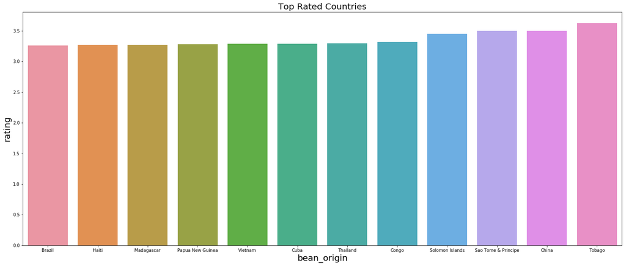

```python
###3a
fig=plt.figure(figsize=(25,10))
plt.xlabel('bean origin',fontsize=20)
plt.ylabel('rating',fontsize=20)
plt.title("Top Rated Countries",fontsize=20)
sns.barplot(x='bean_origin',y='rating', data=country_origin_rating[50:62]);
```

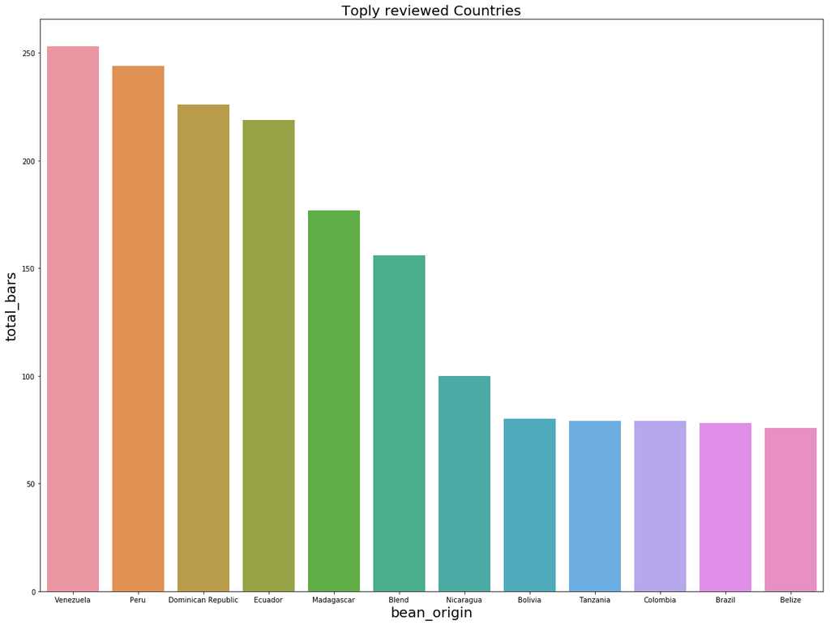

```python
###Question 3b.
fig2=plt.figure(figsize=(20,15))
plt.xlabel('bean_origin',fontsize=20)
plt.ylabel('total_bars',fontsize=20)
plt.title('Toply reviewed Countries',fontsize=20)
sns.barplot('bean_origin','total_bars',data=bar_numbers[0:12]);
```

### Question 4.

Is the cocoa bean origin an indicator of quality?

```python
###APPROACH ONE
quality_indicator=newchoco_bars.groupby('bean_origin').mean().reset_index().sort_values(by='cocoa_percent',ascending=False)
quality_indicator
```

|  | bean_origin | year_reviewed | cocoa_percent | num_ingredients | rating |
| --- | --- | --- | --- | --- | --- |
| 40 | Samoa | 2016.333333 | 82.333333 | 1.666667 | 3.083333 |
| 38 | Principe | 2011.000000 | 77.000000 | 3.000000 | 2.750000 |
| 17 | Gabon | 2013.000000 | 75.000000 | 3.000000 | 3.250000 |
| 11 | Cuba | 2012.666667 | 74.333333 | 3.750000 | 3.291667 |
| 14 | Ecuador | 2012.707763 | 73.276256 | 3.123288 | 3.164384 |
| 1 | Belize | 2016.197368 | 72.855263 | 2.684211 | 3.233553 |
| 22 | Honduras | 2016.400000 | 72.760000 | 2.720000 | 3.240000 |
| 16 | Fiji | 2015.750000 | 72.562500 | 2.687500 | 3.062500 |
| 24 | Indonesia | 2012.650000 | 72.550000 | 3.000000 | 3.112500 |
| 42 | Sao Tome & Principe | 2020.000000 | 72.500000 | 3.500000 | 3.500000 |
| 45 | Sri Lanka | 2010.500000 | 72.500000 | 2.500000 | 2.875000 |
| 61 | Vietnam | 2016.452055 | 72.356164 | 2.945205 | 3.287671 |
| 52 | Tanzania | 2017.126582 | 72.265823 | 2.620253 | 3.234177 |
| 58 | Uganda | 2017.578947 | 72.184211 | 2.789474 | 3.065789 |
| 34 | Panama | 2013.111111 | 72.111111 | 3.111111 | 3.111111 |
| 60 | Venezuela | 2012.703557 | 72.017787 | 3.158103 | 3.231225 |
| 47 | St.Vincent-Grenadines | 2018.000000 | 72.000000 | 4.000000 | 2.750000 |
| 7 | China | 2021.000000 | 72.000000 | 4.000000 | 3.500000 |
| 2 | Blend | 2011.160256 | 71.926282 | 3.666667 | 3.038462 |
| 46 | St. Lucia | 2013.300000 | 71.900000 | 2.900000 | 2.950000 |
| 44 | Solomon Islands | 2017.400000 | 71.800000 | 2.900000 | 3.450000 |
| 56 | Trinidad | 2014.428571 | 71.761905 | 3.119048 | 3.244048 |
| 15 | El Salvador | 2017.666667 | 71.666667 | 3.500000 | 3.000000 |
| 26 | Jamaica | 2012.000000 | 71.625000 | 3.208333 | 3.197917 |
| 29 | Malaysia | 2018.125000 | 71.625000 | 2.500000 | 3.093750 |
| 3 | Bolivia | 2014.725000 | 71.587500 | 2.825000 | 3.181250 |
| 20 | Guatemala | 2016.612903 | 71.548387 | 2.693548 | 3.258065 |
| 13 | Dominican Republic | 2014.597345 | 71.526549 | 2.858407 | 3.215708 |
| 10 | Costa Rica | 2013.441860 | 71.511628 | 2.697674 | 3.151163 |
| 32 | Nicaragua | 2015.890000 | 71.420000 | 2.800000 | 3.255000 |
| ... | ... | ... | ... | ... | ... |
| 28 | Madagascar | 2013.446328 | 71.237288 | 2.994350 | 3.266949 |
| 41 | Sao Tome | 2012.428571 | 71.071429 | 4.000000 | 3.071429 |
| 37 | Philippines | 2017.500000 | 71.062500 | 3.083333 | 3.125000 |
| 18 | Ghana | 2012.853659 | 71.048780 | 3.390244 | 3.134146 |
| 43 | Sierra Leone | 2019.000000 | 71.000000 | 2.500000 | 2.750000 |
| 25 | Ivory Coast | 2013.000000 | 71.000000 | 3.142857 | 2.857143 |
| 59 | Vanuatu | 2015.076923 | 71.000000 | 2.769231 | 3.115385 |
| 8 | Colombia | 2016.202532 | 70.987342 | 3.164557 | 3.196203 |
| 21 | Haiti | 2017.200000 | 70.966667 | 2.966667 | 3.266667 |
| 36 | Peru | 2015.262295 | 70.950820 | 2.938525 | 3.197746 |
| 35 | Papua New Guinea | 2013.740000 | 70.680000 | 3.040000 | 3.280000 |
| 27 | Liberia | 2014.000000 | 70.666667 | 2.333333 | 3.083333 |
| 9 | Congo | 2013.090909 | 70.454545 | 3.454545 | 3.318182 |
| 49 | Sumatra | 2018.000000 | 70.000000 | 2.000000 | 3.000000 |
| 51 | Taiwan | 2018.500000 | 70.000000 | 2.500000 | 2.875000 |
| 50 | Suriname | 2016.000000 | 70.000000 | 2.000000 | 3.250000 |
| 53 | Thailand | 2018.000000 | 70.000000 | 3.000000 | 3.300000 |
| 5 | Burma | 2013.000000 | 70.000000 | 4.000000 | 3.000000 |
| 55 | Togo | 2015.000000 | 70.000000 | 4.000000 | 3.083333 |
| 23 | India | 2018.600000 | 69.571429 | 2.971429 | 3.164286 |
| 19 | Grenada | 2010.842105 | 69.368421 | 3.842105 | 3.026316 |
| 6 | Cameroon | 2017.333333 | 69.333333 | 3.666667 | 3.083333 |
| 57 | U.S.A. | 2013.333333 | 69.242424 | 3.545455 | 3.242424 |
| 0 | Australia | 2014.000000 | 69.000000 | 3.666667 | 3.250000 |
| 33 | Nigeria | 2015.666667 | 68.333333 | 3.333333 | 3.000000 |
| 39 | Puerto Rico | 2016.285714 | 68.285714 | 3.428571 | 2.714286 |
| 12 | DR Congo | 2018.000000 | 68.000000 | 3.000000 | 3.000000 |
| 48 | Sulawesi | 2018.000000 | 66.000000 | 3.000000 | 3.250000 |
| 54 | Tobago | 2012.500000 | 65.000000 | 3.500000 | 3.625000 |
| 30 | Martinique | 2013.000000 | 42.000000 | 4.000000 | 2.750000 |

62 rows × 5 columns

```python
##APPROACH TWO
chocos=newchoco_bars.loc[(newchoco_bars.rating>3.0)] ###3.0 was used as reference cos it was the mean value
chocos
```

| id | manufacturer | company_location | year_reviewed | bean_origin | bar_name | cocoa_percent | num_ingredients | ingredients | review | rating |
| --- | --- | --- | --- | --- | --- | --- | --- | --- | --- | --- |
| 2454 | 5150 | U.S.A. | 2019 | Tanzania | Kokoa Kamili, batch 1 | 76.0 | 3.0 | B,S,C | rich cocoa, fatty, bready | 3.25 |
| 2458 | 5150 | U.S.A. | 2019 | Dominican Republic | Zorzal, batch 1 | 76.0 | 3.0 | B,S,C | cocoa, vegetal, savory | 3.50 |
| 2454 | 5150 | U.S.A. | 2019 | Madagascar | Bejofo Estate, batch 1 | 76.0 | 3.0 | B,S,C | cocoa, blackberry, full body | 3.75 |
| 2546 | 5150 | U.S.A. | 2021 | Uganda | Semuliki Forest, batch 1 | 80.0 | 3.0 | B,S,C | mildly bitter, basic cocoa, fatty | 3.25 |
| 2542 | 5150 | U.S.A. | 2021 | India | Anamalai, batch 1 | 68.0 | 3.0 | B,S,C | milk brownie, macadamia,chewy | 3.50 |
| 797 | A. Morin | France | 2012 | Bolivia | Bolivia | 70.0 | 4.0 | B,S,C,L | vegetal, nutty | 3.50 |
| 797 | A. Morin | France | 2012 | Peru | Peru | 63.0 | 4.0 | B,S,C,L | fruity, melon, roasty | 3.75 |
| 1011 | A. Morin | France | 2013 | Brazil | Brazil | 70.0 | 4.0 | B,S,C,L | mild tobacco | 3.25 |
| 1015 | A. Morin | France | 2013 | Papua New Guinea | Papua New Guinea | 70.0 | 4.0 | B,S,C,L | mild fruit, strong smoke | 3.25 |
| 1019 | A. Morin | France | 2013 | Peru | Piura | 70.0 | 4.0 | B,S,C,L | green, nutty, cocoa | 3.25 |
| 1019 | A. Morin | France | 2013 | Peru | Chanchamayo Province | 70.0 | 4.0 | B,S,C,L | cocoa,sour,intense tangerine | 3.50 |
| 1011 | A. Morin | France | 2013 | Ecuador | Equateur | 70.0 | 4.0 | B,S,C,L | sandy, nutty, cocoa, fig | 3.75 |
| 1015 | A. Morin | France | 2013 | Venezuela | Chuao | 70.0 | 4.0 | B,S,C,L | oily, nut, caramel, raspberry | 4.00 |
| 1019 | A. Morin | France | 2013 | Peru | Chanchamayo Province | 63.0 | 3.0 | B,S,C | sweet, cocoa, tangerine | 4.00 |
| 1315 | A. Morin | France | 2014 | Cuba | Cuba | 70.0 | 4.0 | B,S,C,L | sliglty dry, papaya | 3.50 |
| 1315 | A. Morin | France | 2014 | Venezuela | Sur del Lago, Criollo | 70.0 | 4.0 | B,S,C,L | nutty, mild choco, roasty | 3.50 |
| 1319 | A. Morin | France | 2014 | Venezuela | Puerto Cabello, Criollo | 70.0 | 4.0 | B,S,C,L | astringent, nutty, chocolatey | 3.75 |
| 1319 | A. Morin | France | 2014 | Peru | Pablino | 70.0 | 4.0 | B,S,C,L | delicate, hazelnut, brownie | 4.00 |
| 1680 | A. Morin | France | 2015 | Togo | Akata | 70.0 | 4.0 | B,S,C,L | mild profile, chocolaty, spice | 3.50 |
| 1704 | A. Morin | France | 2015 | Peru | Quilla | 70.0 | 4.0 | B,S,C,L | grainy texture, cocoa, sweet | 3.50 |
| 1876 | A. Morin | France | 2016 | Sao Tome | Agua Grande | 63.0 | 4.0 | B,S,C,L | sweet, chocolatey, vegetal | 3.75 |
| 2206 | A. Morin | France | 2018 | Venezuela | Porcelana | 70.0 | 4.0 | B,S,C,L | alluring aroma, powdery,nutty | 3.50 |
| 2206 | A. Morin | France | 2018 | Peru | Absolu | 63.0 | 4.0 | B,S,C,L | sweet, dairy, spice, cocoa | 3.75 |
| 2648 | A. Morin | France | 2021 | Mexico | La Joya | 70.0 | 4.0 | B,S,C,L | light color, fruit, yogurt | 4.00 |
| 1462 | Acalli | U.S.A. | 2015 | Peru | Chulucanas, El Platanal, batch 001 | 70.0 | 2.0 | B,S | yellow fruit | 3.75 |
| 1470 | Acalli | U.S.A. | 2015 | Peru | Tumbes, Norandino | 70.0 | 2.0 | B,S | intense, nutty, cherry, cocoa | 3.75 |
| 2462 | Acalli | U.S.A. | 2020 | Mexico | Teapa, Tabasco, batch 2 | 74.0 | 2.0 | B,S | herbal, molasses, hammy | 3.25 |
| 2470 | Acalli | U.S.A. | 2020 | Peru | Barataria, El Plantal and Norandino Tumbes blend | 70.0 | 2.0 | B,S | hot cocoa, rich, molasses | 3.50 |
| 705 | Adi aka Fijiana (Easy In Ltd) | Fiji | 2011 | Fiji | Vanua Levu, Toto-A | 80.0 | 3.0 | B,S,C | spicy and candy-like | 3.25 |
| 705 | Adi aka Fijiana (Easy In Ltd) | Fiji | 2011 | Fiji | Vanua Levu | 88.0 | 3.0 | B,S,C | orange, floral, lemon | 3.50 |
| ... | ... | ... | ... | ... | ... | ... | ... | ... | ... | ... |
| 2618 | Zac Squared | U.S.A. | 2021 | Vietnam | Ben Tre | 70.0 | 3.0 | B,S,C | tart, cherry, cocoa, mild sour | 3.50 |
| 2618 | Zac Squared | U.S.A. | 2021 | Dominican Republic | Zorzal | 70.0 | 3.0 | B,S,C | sweet, rich, cocoa, fruity | 3.50 |
| 1578 | Zak's | U.S.A. | 2015 | Dominican Republic | Dominican Republic, Batch D2 | 70.0 | 3.0 | B,S,C | nutty, earthy, hammy | 3.25 |
| 1578 | Zak's | U.S.A. | 2015 | Madagascar | Madagascar, Batch 2 | 70.0 | 3.0 | B,S,C | sandy, mild sour, mild fruit | 3.25 |
| 1578 | Zak's | U.S.A. | 2015 | Peru | Peru, Batch 1 | 70.0 | 3.0 | B,S,C | sandy, nutty, mocha | 3.25 |
| 1578 | Zak's | U.S.A. | 2015 | Belize | Belize, Batch 2 | 70.0 | 3.0 | B,S,C | rich base cocoa, sweet | 3.50 |
| 1820 | Zart Pralinen | Austria | 2016 | Madagascar | Millot P., Ambanja | 70.0 | 3.0 | B,S,C | sticky, mellow choco, dairy | 3.50 |
| 1824 | Zart Pralinen | Austria | 2016 | Tanzania | Kakao Kamili, Kilombero Valley | 70.0 | 3.0 | B,S,C | smoke, tart, burnt cocoa | 3.50 |
| 1880 | Zart Pralinen | Austria | 2016 | Trinidad | San Juan Estate, Gran Couva | 78.0 | 2.0 | B,S | tobacco, over roasted | 3.50 |
| 697 | Zokoko | Australia | 2011 | Bolivia | Alto Beni | 68.0 | 4.0 | B,S,C,L | oily, honey, light rum | 3.50 |
| 701 | Zokoko | Australia | 2011 | Papua New Guinea | Tokiala | 66.0 | 4.0 | B,S,C,L | toffee, caramel, butterscotch | 3.50 |
| 701 | Zokoko | Australia | 2011 | Bolivia | Tranquilidad, Baures | 72.0 | 4.0 | B,S,C,L | intense prune and berry | 3.75 |
| 1780 | Zokoko | Australia | 2016 | Blend | Goddess Blend | 65.0 | 5.0 | B,S,C,V,L | oily, sweet, choco, nutty | 3.25 |
| 1716 | Zokoko | Australia | 2016 | Solomon Islands | Guadalcanal | 78.0 | 4.0 | B,S,C,L | smokey, dried fruit, balanced | 3.75 |
| 2064 | Zoto (Chocolatoa) | Belgium | 2018 | Nicaragua | Rugoso | 75.0 | 3.0 | B,S,C | sandy, basic cocoa | 3.25 |
| 2048 | Zoto (Chocolatoa) | Belgium | 2018 | Nicaragua | El Castillero, batch ca1705, 3 turns | 70.0 | 3.0 | B,S,C | large grits, sweet, dried fruit | 3.75 |
| 781 | Zotter | Austria | 2011 | India | Kerala State | 62.0 | 4.0 | B,S*,C,Sa | oily, subdued, caramel, salt | 3.25 |
| 749 | Zotter | Austria | 2011 | India | Kerala State | 65.0 | 4.0 | B,S*,C,Sa | creamy, masculine, earthy | 3.50 |
| 647 | Zotter | Austria | 2011 | Peru | Peru | 70.0 | 4.0 | B,S*,C,Sa | creamy, fatty, mild nutty | 3.75 |
| 879 | Zotter | Austria | 2012 | Bolivia | El Ceibo Coop | 90.0 | 4.0 | B,S*,C,Sa | smooth, intense blueberry | 3.25 |
| 883 | Zotter | Austria | 2012 | Congo | Kongo, Highlands | 68.0 | 4.0 | B,S*,C,Sa | creamy, caramel, salt, sweet | 3.25 |
| 801 | Zotter | Austria | 2012 | Panama | Bocas del Toro, Cocabo Co-op | 72.0 | 4.0 | B,S*,C,Sa | oily, earthy, caramel, salty | 3.50 |
| 801 | Zotter | Austria | 2012 | Blend | Amazonas Frucht | 65.0 | 4.0 | B,S*,C,Sa | dairy, burnt caramel, coffee | 3.50 |
| 875 | Zotter | Austria | 2012 | Peru | Satipo Pangoa region, 20hr conche | 70.0 | 4.0 | B,S*,C,Sa | butterscotch, pepper | 3.50 |
| 883 | Zotter | Austria | 2012 | Blend | Indianer, Raw | 58.0 | 4.0 | B,S*,C,Sa | smooth, spicy, floral | 3.50 |
| 875 | Zotter | Austria | 2012 | Dominican Republic | Loma Los Pinos, Yacao region, D.R. | 62.0 | 4.0 | B,S*,C,Sa | spice, caramel, toffee, salty | 3.75 |
| 879 | Zotter | Austria | 2012 | Dominican Republic | Santo Domingo | 70.0 | 4.0 | B,S*,C,Sa | strawberry, Cadbury egg | 3.75 |
| 1996 | Zotter | Austria | 2017 | Colombia | APROCAFA, Acandi | 75.0 | 3.0 | B,S,C | strong nutty, marshmallow | 3.75 |
| 2170 | Zotter | Austria | 2018 | Congo | Mountains of the Moon | 70.0 | 3.0 | B,S,C | fatty, mild nuts, mild fruit | 3.25 |
| 2170 | Zotter | Austria | 2018 | Belize | Maya Mtn | 72.0 | 3.0 | B,S,C | muted, roasty, accessible | 3.50 |

1441 rows × 10 columns

```python
###APPROACH TWO CONTD
choco2=newchoco_bars.loc[(newchoco_bars.cocoa_percent>71)] ### 71% was used as reference cos it was the mean value
choco2
```

| id | manufacturer | company_location | year_reviewed | bean_origin | bar_name | cocoa_percent | num_ingredients | ingredients | review | rating |
| --- | --- | --- | --- | --- | --- | --- | --- | --- | --- | --- |
| 2454 | 5150 | U.S.A. | 2019 | Tanzania | Kokoa Kamili, batch 1 | 76.0 | 3.0 | B,S,C | rich cocoa, fatty, bready | 3.25 |
| 2458 | 5150 | U.S.A. | 2019 | Dominican Republic | Zorzal, batch 1 | 76.0 | 3.0 | B,S,C | cocoa, vegetal, savory | 3.50 |
| 2454 | 5150 | U.S.A. | 2019 | Madagascar | Bejofo Estate, batch 1 | 76.0 | 3.0 | B,S,C | cocoa, blackberry, full body | 3.75 |
| 2546 | 5150 | U.S.A. | 2021 | Venezuela | Sur del Lago, batch 1 | 72.0 | 3.0 | B,S,C | fatty, earthy, moss, nutty,chalky | 3.00 |
| 2546 | 5150 | U.S.A. | 2021 | Uganda | Semuliki Forest, batch 1 | 80.0 | 3.0 | B,S,C | mildly bitter, basic cocoa, fatty | 3.25 |
| 2462 | Acalli | U.S.A. | 2020 | Mexico | Teapa, Tabasco, batch 2 | 74.0 | 2.0 | B,S | herbal, molasses, hammy | 3.25 |
| 705 | Adi aka Fijiana (Easy In Ltd) | Fiji | 2011 | Fiji | Vanua Levu, Toto-A | 80.0 | 3.0 | B,S,C | spicy and candy-like | 3.25 |
| 705 | Adi aka Fijiana (Easy In Ltd) | Fiji | 2011 | Fiji | Vanua Levu | 88.0 | 3.0 | B,S,C | orange, floral, lemon | 3.50 |
| 705 | Adi aka Fijiana (Easy In Ltd) | Fiji | 2011 | Fiji | Vanua Levu, Ami-Ami-CA | 72.0 | 3.0 | B,S,C | cocoa and powerful tang | 3.50 |
| 502 | Akesson's (Pralus) | U.K. | 2010 | Madagascar | Madagascar, Ambolikapiky P. | 75.0 | 4.0 | B,S,C,L | strong pepper, musty | 2.75 |
| 508 | Akesson's (Pralus) | U.K. | 2010 | Brazil | Monte Alegre, D. Badero | 75.0 | 4.0 | B,S,C,L | fatty, intense, woody | 2.75 |
| 636 | Akesson's (Pralus) | U.K. | 2011 | Indonesia | Bali (west), Sukrama Family, Melaya area | 75.0 | 4.0 | B,S,C,L | hay, nut, berry | 3.75 |
| 1061 | Alain Ducasse | France | 2013 | Venezuela | Chuao | 75.0 | 5.0 | B,S,C,V,L | sandy, dirt, ashey | 2.50 |
| 1173 | Alain Ducasse | France | 2013 | Peru | Piura, Perou | 75.0 | 5.0 | B,S,C,V,L | cardboard, dirt, roasty | 2.50 |
| 1215 | Alain Ducasse | France | 2014 | Vietnam | Vietnam | 75.0 | 5.0 | B,S,C,V,Sa | nutty, roasty, odd dairy | 2.75 |
| 1215 | Alain Ducasse | France | 2014 | Madagascar | Madagascar | 75.0 | 5.0 | B,S,C,V,Sa | citrus, fatty, dairy | 3.00 |
| 1992 | Alain Ducasse | France | 2017 | Mexico | Porcelana, Mexique | 75.0 | 6.0 | B,S,C,V,L,Sa | strawberry, cream, gateway | 3.50 |
| 1129 | Altus aka Cao Artisan | U.S.A. | 2013 | Bolivia | Bolivia, batch 101 | 80.0 | 4.0 | B,S,C,L | gritty, berry, mild bitter | 3.25 |
| 464 | Amatller (Simon Coll) | Spain | 2009 | Ecuador | Ecuador | 85.0 | 2.0 | B,S | fatty, mushroom, off notes | 2.75 |
| 464 | Amatller (Simon Coll) | Spain | 2009 | Ghana | Ghana | 85.0 | 2.0 | B,S | roasty,oddly sweet,marshmallow | 3.00 |
| 1145 | Amazona | Peru | 2013 | Peru | LamasdelChanka, San Martin, Oro Verde coop | 72.0 | 3.0 | B,S,C | oily, vanilla, melon, cocoa | 3.25 |
| 1145 | Amazona | Peru | 2013 | Peru | Bellavista Gran Pajeten, San Martin | 73.0 | 3.0 | B,S,C | oily, vegetal, nutty, cocoa | 3.50 |
| 1498 | Ambrosia | Canada | 2015 | Dominican Republic | Dominican Republic | 75.0 | 2.0 | B,S | high roast, high astringnet | 3.25 |
| 2092 | Amedei | Italy | 2018 | Blend | Nine | 75.0 | 4.0 | B,S,C,V | sweet, delicate, complex | 3.50 |
| 572 | AMMA | Brazil | 2010 | Brazil | Monte Alegre, 3 diff. plantations | 85.0 | 4.0 | B,S,C,L | creamy, red berry, bitter | 2.75 |
| 572 | AMMA | Brazil | 2010 | Brazil | Monte Alegre, 3 diff. plantations | 75.0 | 4.0 | B,S,C,L | roasty, fatty, nutty, coffee | 3.75 |
| 1065 | AMMA | Brazil | 2013 | Brazil | Catongo | 75.0 | 4.0 | B,S,C,L | grainy, sweet, poor aftertaste | 3.25 |
| 1259 | Anahata | U.S.A. | 2014 | Dominican Republic | Elvesia | 75.0 | 2.0 | B,S | chalky, mild fruit, burnt | 3.00 |
| 1852 | Animas | U.S.A. | 2016 | Bolivia | Alto Beni | 75.0 | 2.0 | B,S | light roast, caramel, cocoa | 3.50 |
| 2586 | Animas | U.S.A. | 2021 | Belize | Maya Mountain, batch 39 | 75.0 | 2.0 | B,S | burnt toast, cherry | 3.00 |
| ... | ... | ... | ... | ... | ... | ... | ... | ... | ... | ... |
| 733 | Whittakers | New Zealand | 2011 | Ghana | Ghana | 72.0 | 3.0 | B,S,V | sticky, dry, vanilla dominates | 2.50 |
| 1169 | Wilkie's Organic | Ireland | 2013 | Peru | Amazonas | 75.0 | 3.0 | B,S,C | light color, grit, metallic | 2.50 |
| 1169 | Wilkie's Organic | Ireland | 2013 | Peru | Amazonas | 89.0 | 3.0 | B,S,C | slow develop, bitter, metallic | 2.75 |
| 1173 | Wilkie's Organic | Ireland | 2013 | Peru | Amazonas w/ nibs | 75.0 | 3.0 | B,S,C | mild, metallic | 2.75 |
| 1169 | Wilkie's Organic | Ireland | 2013 | Peru | Tumbes | 75.0 | 3.0 | B,S,C | sandy, sweet, coffee | 3.25 |
| 457 | Willie's Cacao | U.K. | 2009 | Venezuela | Rio Caribe | 72.0 | 3.0 | B,S,C | creamy, earthy, nutty | 3.25 |
| 593 | Willie's Cacao | U.K. | 2010 | Venezuela | Hacienda Las Trincheras | 72.0 | 3.0 | B,S,C | dry, nutty, cocoa | 3.50 |
| 1109 | Willie's Cacao | U.K. | 2013 | Indonesia | Java, Indonesian Black | 100.0 | 3.0 | B,S,V | fruit, strong smoke, bitter | 2.25 |
| 1227 | Willie's Cacao | U.K. | 2014 | Colombia | Los Llanos | 88.0 | 3.0 | B,S,C | mild nutty and fruit, savory | 3.00 |
| 1912 | Wm | U.S.A. | 2016 | Venezuela | Guasare, Zulia Prov., 2015, batch 124 | 74.0 | 3.0 | B,S,C | nutty, rubber | 3.00 |
| 1912 | Wm | U.S.A. | 2016 | Bolivia | Wild Beniano, 2016, batch 128, Heirloom | 76.0 | 3.0 | B,S,C | nutty, fig, short length | 3.50 |
| 1916 | Wm | U.S.A. | 2016 | Ghana | Ghana, 2013, batch 129 | 75.0 | 3.0 | B,S,C | strong malt, choco pudding | 3.75 |
| 2378 | Xocolatisimo | El Salvador | 2019 | El Salvador | Hacienda San Jose | 75.0 | 4.0 | B,S,C,L | coarse, sweet, candy, licorice | 3.00 |
| 2522 | Xocolatl | U.S.A. | 2020 | Tanzania | Kokoa Kamili, Kilombero Valley, batch 1 | 73.0 | 2.0 | B,S | sandy, earthy, hint of tang | 3.25 |
| 2522 | Xocolatl | U.S.A. | 2020 | Nicaragua | Matagalpa, batch 57 | 72.0 | 2.0 | B,S | sandy, roasty, fig, late spiciness | 3.50 |
| 1824 | Zart Pralinen | Austria | 2016 | Trinidad | San Juan Estate | 85.0 | 3.0 | B,S,C | sticky, strong bitter, spice | 2.75 |
| 1824 | Zart Pralinen | Austria | 2016 | Tanzania | Kakao Kamili, Kilombero Valley | 85.0 | 3.0 | B,S,C | melon, mild tart, bitter, fatty | 3.00 |
| 1880 | Zart Pralinen | Austria | 2016 | Trinidad | San Juan Estate, Gran Couva | 78.0 | 2.0 | B,S | tobacco, over roasted | 3.50 |
| 701 | Zokoko | Australia | 2011 | Bolivia | Tranquilidad, Baures | 72.0 | 4.0 | B,S,C,L | intense prune and berry | 3.75 |
| 1716 | Zokoko | Australia | 2016 | Solomon Islands | Guadalcanal | 78.0 | 4.0 | B,S,C,L | smokey, dried fruit, balanced | 3.75 |
| 2044 | Zoto (Chocolatoa) | Belgium | 2018 | Nicaragua | Jeru Antiguo, batch jan705, 2 turns | 72.0 | 3.0 | B,S,C | intense earthy | 3.00 |
| 2064 | Zoto (Chocolatoa) | Belgium | 2018 | Nicaragua | Rugoso | 75.0 | 3.0 | B,S,C | sandy, basic cocoa | 3.25 |
| 879 | Zotter | Austria | 2012 | Ecuador | El Oro | 75.0 | 4.0 | B,S*,C,Sa | creamy, nutty, bready | 3.00 |
| 879 | Zotter | Austria | 2012 | Papua New Guinea | Huiwani Coop | 75.0 | 4.0 | B,S*,C,Sa | hint of smoke, fruit | 3.00 |
| 879 | Zotter | Austria | 2012 | Bolivia | El Ceibo Coop | 90.0 | 4.0 | B,S*,C,Sa | smooth, intense blueberry | 3.25 |
| 801 | Zotter | Austria | 2012 | Panama | Bocas del Toro, Cocabo Co-op | 72.0 | 4.0 | B,S*,C,Sa | oily, earthy, caramel, salty | 3.50 |
| 1205 | Zotter | Austria | 2014 | Blend | Raw | 80.0 | 4.0 | B,S*,C,Sa | waxy, cloying, vegetal | 2.75 |
| 1996 | Zotter | Austria | 2017 | Colombia | APROCAFA, Acandi | 75.0 | 3.0 | B,S,C | strong nutty, marshmallow | 3.75 |
| 2036 | Zotter | Austria | 2018 | Blend | Dry Aged, 30 yr Anniversary bar | 75.0 | 3.0 | B,S,C | fatty, earthy, cocoa | 3.00 |
| 2170 | Zotter | Austria | 2018 | Belize | Maya Mtn | 72.0 | 3.0 | B,S,C | muted, roasty, accessible | 3.50 |

1055 rows × 10 columns

```python
newchocos=newchoco_bars.loc[(newchoco_bars.rating>3.0)&(newchoco_bars.cocoa_percent>71)]
newchocos
```

| id | manufacturer | company_location | year_reviewed | bean_origin | bar_name | cocoa_percent | num_ingredients | ingredients | review | rating |
| --- | --- | --- | --- | --- | --- | --- | --- | --- | --- | --- |
| 2454 | 5150 | U.S.A. | 2019 | Tanzania | Kokoa Kamili, batch 1 | 76.0 | 3.0 | B,S,C | rich cocoa, fatty, bready | 3.25 |
| 2458 | 5150 | U.S.A. | 2019 | Dominican Republic | Zorzal, batch 1 | 76.0 | 3.0 | B,S,C | cocoa, vegetal, savory | 3.50 |
| 2454 | 5150 | U.S.A. | 2019 | Madagascar | Bejofo Estate, batch 1 | 76.0 | 3.0 | B,S,C | cocoa, blackberry, full body | 3.75 |
| 2546 | 5150 | U.S.A. | 2021 | Uganda | Semuliki Forest, batch 1 | 80.0 | 3.0 | B,S,C | mildly bitter, basic cocoa, fatty | 3.25 |
| 2462 | Acalli | U.S.A. | 2020 | Mexico | Teapa, Tabasco, batch 2 | 74.0 | 2.0 | B,S | herbal, molasses, hammy | 3.25 |
| 705 | Adi aka Fijiana (Easy In Ltd) | Fiji | 2011 | Fiji | Vanua Levu, Toto-A | 80.0 | 3.0 | B,S,C | spicy and candy-like | 3.25 |
| 705 | Adi aka Fijiana (Easy In Ltd) | Fiji | 2011 | Fiji | Vanua Levu | 88.0 | 3.0 | B,S,C | orange, floral, lemon | 3.50 |
| 705 | Adi aka Fijiana (Easy In Ltd) | Fiji | 2011 | Fiji | Vanua Levu, Ami-Ami-CA | 72.0 | 3.0 | B,S,C | cocoa and powerful tang | 3.50 |
| 636 | Akesson's (Pralus) | U.K. | 2011 | Indonesia | Bali (west), Sukrama Family, Melaya area | 75.0 | 4.0 | B,S,C,L | hay, nut, berry | 3.75 |
| 1992 | Alain Ducasse | France | 2017 | Mexico | Porcelana, Mexique | 75.0 | 6.0 | B,S,C,V,L,Sa | strawberry, cream, gateway | 3.50 |
| 1129 | Altus aka Cao Artisan | U.S.A. | 2013 | Bolivia | Bolivia, batch 101 | 80.0 | 4.0 | B,S,C,L | gritty, berry, mild bitter | 3.25 |
| 1145 | Amazona | Peru | 2013 | Peru | LamasdelChanka, San Martin, Oro Verde coop | 72.0 | 3.0 | B,S,C | oily, vanilla, melon, cocoa | 3.25 |
| 1145 | Amazona | Peru | 2013 | Peru | Bellavista Gran Pajeten, San Martin | 73.0 | 3.0 | B,S,C | oily, vegetal, nutty, cocoa | 3.50 |
| 1498 | Ambrosia | Canada | 2015 | Dominican Republic | Dominican Republic | 75.0 | 2.0 | B,S | high roast, high astringnet | 3.25 |
| 2092 | Amedei | Italy | 2018 | Blend | Nine | 75.0 | 4.0 | B,S,C,V | sweet, delicate, complex | 3.50 |
| 572 | AMMA | Brazil | 2010 | Brazil | Monte Alegre, 3 diff. plantations | 75.0 | 4.0 | B,S,C,L | roasty, fatty, nutty, coffee | 3.75 |
| 1065 | AMMA | Brazil | 2013 | Brazil | Catongo | 75.0 | 4.0 | B,S,C,L | grainy, sweet, poor aftertaste | 3.25 |
| 1852 | Animas | U.S.A. | 2016 | Bolivia | Alto Beni | 75.0 | 2.0 | B,S | light roast, caramel, cocoa | 3.50 |
| 2586 | Animas | U.S.A. | 2021 | Guatemala | Alta Verapaz, Cahabon & Lanquin regions, b. 4243 | 75.0 | 2.0 | B,S | orange citrus, harsh earthiness | 3.25 |
| 1602 | Arete | U.S.A. | 2015 | Ecuador | Camino Verde | 75.0 | 3.0 | B,S,C | intense, floral, bourbon | 3.50 |
| 1928 | Arete | U.S.A. | 2016 | Vietnam | Lam Dong | 73.0 | 2.0 | B,S | earthy, nutty, cardboard | 3.25 |
| 1900 | Arete | U.S.A. | 2016 | Vietnam | Tien Giang | 73.0 | 3.0 | B,S,C | cashew, roasty, chunky melt | 3.50 |
| 2020 | Arete | U.S.A. | 2017 | Vietnam | Ben Tre | 73.0 | 3.0 | B,S,C | rich cocoa, mild roasty | 3.50 |
| 300 | Artisan du Chocolat | U.K. | 2008 | Congo | Congo | 72.0 | 3.0 | B,S,C | spicy, minty, vegetal | 3.75 |
| 363 | Artisan du Chocolat | U.K. | 2009 | Dominican Republic | Dominican Republic | 72.0 | 3.0 | B,S,C | spice, cocoa, short | 3.25 |
| 600 | Artisan du Chocolat | U.K. | 2010 | Costa Rica | Costa Rica | 72.0 | 3.0 | B,S,C | chewy, grassy, nutty | 3.25 |
| 600 | Artisan du Chocolat | U.K. | 2010 | Vietnam | Ba Ria Vung Tau Province | 72.0 | 3.0 | B,S,C | unrefined, distinct spicey | 3.25 |
| 600 | Artisan du Chocolat | U.K. | 2010 | Indonesia | Bali | 72.0 | 3.0 | B,S,C | black pepper and banana | 3.50 |
| 531 | Artisan du Chocolat | U.K. | 2010 | Jamaica | Jamaica | 72.0 | 3.0 | B,S,C | grassy, black licorice, mint | 3.75 |
| 729 | Artisan du Chocolat | U.K. | 2011 | Haiti | Haiti | 72.0 | 3.0 | B,S,C | nuts, butterscotch, brownie | 4.00 |
| ... | ... | ... | ... | ... | ... | ... | ... | ... | ... | ... |
| 1700 | twenty-four blackbirds | U.S.A. | 2015 | Ecuador | Cedeno, lot 271 | 75.0 | 2.0 | B,S | intense, floral | 3.50 |
| 1996 | twenty-four blackbirds | U.S.A. | 2017 | Tanzania | Kokoa Kamili | 75.0 | 2.0 | B,S | dry, floral, woody | 3.25 |
| 2004 | Uncouth | Canada | 2017 | Guatemala | Guatemala | 75.0 | 2.0 | B,S | dry, coarse, sour | 3.25 |
| 1752 | Upchurch | U.S.A. | 2016 | Tanzania | Tanzania, Party Bar | 72.0 | 2.0 | B,S | sandy, sweet, peach | 3.25 |
| 2478 | Vaka | Canada | 2020 | Belize | Maya Mountain, Toledo, batch 91 | 74.0 | 3.0 | B,S,C | roasted strawberry, bold | 3.50 |
| 1117 | Videri | U.S.A. | 2013 | Blend | Dark, Central and S. America | 90.0 | 3.0 | B,S,C | mellow fruit, tart, mild bitter | 3.75 |
| 1211 | Videri | U.S.A. | 2014 | Dominican Republic | Dominican Republic | 90.0 | 3.0 | B,S,C | intense, cocoa, spicy, fruit | 3.25 |
| 1211 | Videri | U.S.A. | 2014 | Trinidad | Trinidad | 75.0 | 3.0 | B,S,C | spicy, roasty, acidic, dairy | 3.50 |
| 1227 | Videri | U.S.A. | 2014 | Ecuador | Mindo | 75.0 | 3.0 | B,S,C | spicy, nutmeg, brownie | 3.50 |
| 2578 | Videri | U.S.A. | 2021 | Ecuador | Costas Esmeraldas | 75.0 | 2.0 | B,S | floral & fruit | 3.50 |
| 1458 | Violet Sky | U.S.A. | 2015 | Peru | Peru | 77.0 | 2.0 | B,S | chalky, peach, bland | 3.25 |
| 2626 | White Label aka Mutari | U.S.A. | 2021 | Philippines | Kablon Farms, b. KP7417211821 | 74.0 | 3.0 | B,S,C | nutty, roasted cherry, coffee | 3.50 |
| 2626 | White Label aka Mutari | U.S.A. | 2021 | Uganda | Semuliki, 2017-18 h., batch SU72conche22212621 | 72.0 | 3.0 | B,S,C | nutty, cocoa, yogurt | 3.50 |
| 2622 | White Label aka Mutari | U.S.A. | 2021 | Honduras | La Masica, 2015 harvest, b. LH74HORZConcheV2 | 74.0 | 2.0 | B,S | brownie, nutty, roasty | 3.75 |
| 2622 | White Label aka Mutari | U.S.A. | 2021 | Trinidad | Garcia Estate, 2019 harvest, b. GT722162021820 | 72.0 | 3.0 | B,S,C | complex, mild tobacco, nut, fruit | 3.75 |
| 1169 | Wilkie's Organic | Ireland | 2013 | Peru | Tumbes | 75.0 | 3.0 | B,S,C | sandy, sweet, coffee | 3.25 |
| 457 | Willie's Cacao | U.K. | 2009 | Venezuela | Rio Caribe | 72.0 | 3.0 | B,S,C | creamy, earthy, nutty | 3.25 |
| 593 | Willie's Cacao | U.K. | 2010 | Venezuela | Hacienda Las Trincheras | 72.0 | 3.0 | B,S,C | dry, nutty, cocoa | 3.50 |
| 1912 | Wm | U.S.A. | 2016 | Bolivia | Wild Beniano, 2016, batch 128, Heirloom | 76.0 | 3.0 | B,S,C | nutty, fig, short length | 3.50 |
| 1916 | Wm | U.S.A. | 2016 | Ghana | Ghana, 2013, batch 129 | 75.0 | 3.0 | B,S,C | strong malt, choco pudding | 3.75 |
| 2522 | Xocolatl | U.S.A. | 2020 | Tanzania | Kokoa Kamili, Kilombero Valley, batch 1 | 73.0 | 2.0 | B,S | sandy, earthy, hint of tang | 3.25 |
| 2522 | Xocolatl | U.S.A. | 2020 | Nicaragua | Matagalpa, batch 57 | 72.0 | 2.0 | B,S | sandy, roasty, fig, late spiciness | 3.50 |
| 1880 | Zart Pralinen | Austria | 2016 | Trinidad | San Juan Estate, Gran Couva | 78.0 | 2.0 | B,S | tobacco, over roasted | 3.50 |
| 701 | Zokoko | Australia | 2011 | Bolivia | Tranquilidad, Baures | 72.0 | 4.0 | B,S,C,L | intense prune and berry | 3.75 |
| 1716 | Zokoko | Australia | 2016 | Solomon Islands | Guadalcanal | 78.0 | 4.0 | B,S,C,L | smokey, dried fruit, balanced | 3.75 |
| 2064 | Zoto (Chocolatoa) | Belgium | 2018 | Nicaragua | Rugoso | 75.0 | 3.0 | B,S,C | sandy, basic cocoa | 3.25 |
| 879 | Zotter | Austria | 2012 | Bolivia | El Ceibo Coop | 90.0 | 4.0 | B,S*,C,Sa | smooth, intense blueberry | 3.25 |
| 801 | Zotter | Austria | 2012 | Panama | Bocas del Toro, Cocabo Co-op | 72.0 | 4.0 | B,S*,C,Sa | oily, earthy, caramel, salty | 3.50 |
| 1996 | Zotter | Austria | 2017 | Colombia | APROCAFA, Acandi | 75.0 | 3.0 | B,S,C | strong nutty, marshmallow | 3.75 |
| 2170 | Zotter | Austria | 2018 | Belize | Maya Mtn | 72.0 | 3.0 | B,S,C | muted, roasty, accessible | 3.50 |

539 rows × 10 columns

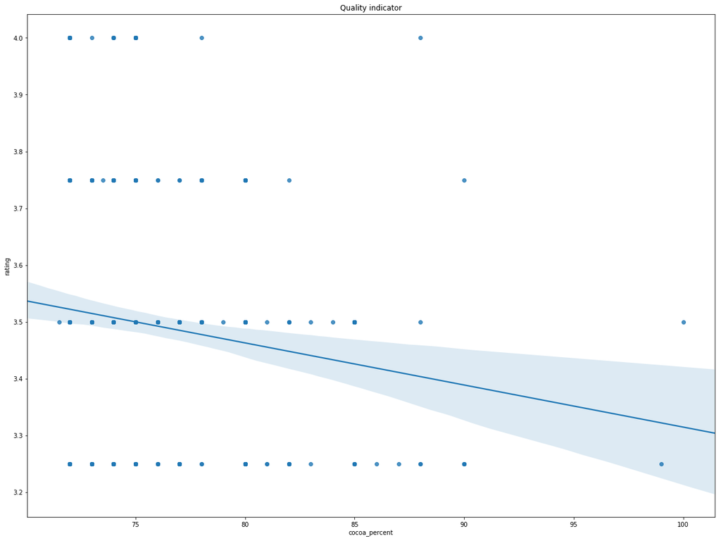

```python
###FINAL APPROACH TWO
plt.figure(figsize=(20,15))
plt.title('Quality indicator')
sns.regplot(x='cocoa_percent',y='rating',data=newchocos);
```

### Observation

Theree is no correlation betweeen either cocoa_percent, ratings or both to quality of bean obtained from countries producing cocoa

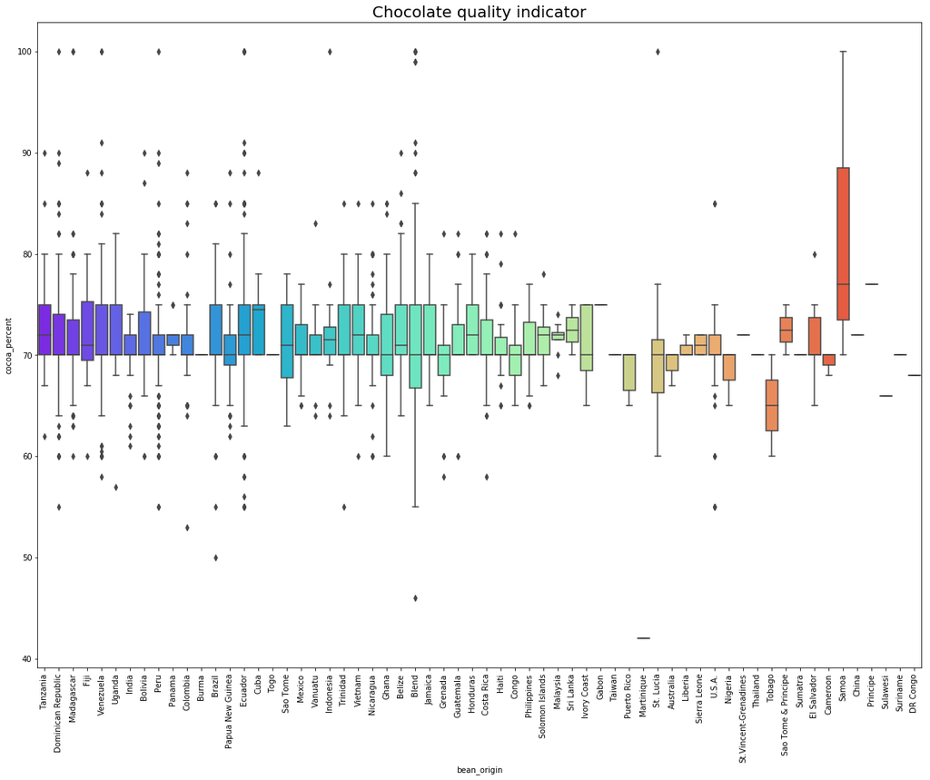

```python
###PREFERRED APPROACH.
###cocoa_percent was chosen as a measure of quality as it is more objective when compared to rating which is subjective.
###APPROACH THREE. This is simpler and could be used to answer the indicator quality question.

figure4=plt.figure(figsize=(20,15))
sns.boxplot(x='bean_origin',y='cocoa_percent',data=newchoco_bars,palette='rainbow')
plt.title('Chocolate quality indicator',fontsize=20)
plt.xticks(rotation=90);
```

### Observation

Bean origin is not an indicator of quality. There are so many outliers.

### Question 5.

How does cocoa content relate to rating? What is the average cocoa content of bars with higher rating (above 3.5)

```python
cocoa_content_rating=newchoco_bars.corr()
cocoa_content_rating
```

|  | year_reviewed | cocoa_percent | num_ingredients | rating |
| --- | --- | --- | --- | --- |
| year_reviewed | 1.000000 | 0.016484 | -0.354428 | 0.116256 |
| cocoa_percent | 0.016484 | 1.000000 | -0.170263 | -0.146690 |
| num_ingredients | -0.354428 | -0.170263 | 1.000000 | -0.092046 |
| rating | 0.116256 | -0.146690 | -0.092046 | 1.000000 |

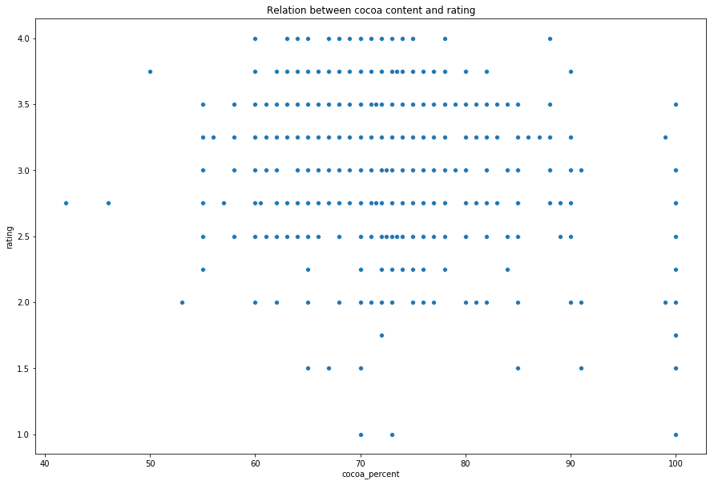

```python
fig3=plt.figure(figsize=(15,10))
plt.title('Relation between cocoa content and rating')
plt.xlabel('cocoa percent')
plt.ylabel('rating')
cocoa_percent_rating=sns.scatterplot(x='cocoa_percent',y='rating',data=newchoco_bars)
```

### Observation

From the result depicited on the correlation table (-0.146690), cocoa content relates to rating to a low degree. This may be implied that a higher cocoa percent is not indicative of a high rating. This was also observed from the scatterplot diagram, where a 100% cocoa content were rated variedly by consumers (from between unpleasant to disappointing and recommended).

### Question 5b

What is the average cocoa content of bars with higher rating (above 3.5)

```python
topavgcocoa=newchoco_bars[newchoco_bars.rating>3.5].cocoa_percent.mean()
topavgcocoa
```

```
70.94781553398059
```

### Question 6.

Compare average rating of bars with and without lecithin

```python
newchoco_bars.ingredients.unique()
```

```
array(['B,S,C', 'B,S,C,L', 'B,S', 'B,S,C,V', 'B,S,C,V,L', 'B,S,C,V,L,Sa',
       'B,S,C,V,Sa', 'B,S,V', 'B,S,V,L', 'B,S*', 'B', 'B,S*,C', 'B,S,L',
       'B,S*,C,L', 'B,S*,C,Sa', 'B,S*,Sa', 'B,S,C,Sa', 'B,S*,V,L', 'B,C',
       'B,S*,C,V', 'B,S,C,L,Sa'], dtype=object)
```

```python
newchoco_bars.ingredients.value_counts()
```

```
B,S,C           999
B,S             718
B,S,C,L         286
B,S,C,V,L       184
B,S,C,V         141
B,S,V            90
B,S*             31
B,S*,C,Sa        20
B,S*,C           12
B,S,L             8
B,S*,C,V          7
B                 6
B,S,C,V,Sa        6
B,S,V,L           5
B,S,C,Sa          5
B,S,C,V,L,Sa      4
B,S*,V,L          3
B,S*,C,L          2
B,C               1
B,S,C,L,Sa        1
B,S*,Sa           1
Name: ingredients, dtype: int64
```

```python
L_ingredients=newchoco_bars.loc[newchoco_bars['ingredients'].isin(['B,S,C,L','B,S,C,V,L','B,S,L','B,S,V,L','B,S*,V,L','B,S*,C,L','B,S,C,L,Sa'])]
L_ingredients
```

| id | manufacturer | company_location | year_reviewed | bean_origin | bar_name | cocoa_percent | num_ingredients | ingredients | review | rating |
| --- | --- | --- | --- | --- | --- | --- | --- | --- | --- | --- |
| 797 | A. Morin | France | 2012 | Bolivia | Bolivia | 70.0 | 4.0 | B,S,C,L | vegetal, nutty | 3.50 |
| 797 | A. Morin | France | 2012 | Peru | Peru | 63.0 | 4.0 | B,S,C,L | fruity, melon, roasty | 3.75 |
| 1011 | A. Morin | France | 2013 | Panama | Panama | 70.0 | 4.0 | B,S,C,L | brief fruit note, earthy, nutty | 2.75 |
| 1015 | A. Morin | France | 2013 | Colombia | Colombie | 70.0 | 4.0 | B,S,C,L | burnt rubber,alkalyzed notes | 2.75 |
| 1011 | A. Morin | France | 2013 | Madagascar | Madagascar, Criollo | 70.0 | 4.0 | B,S,C,L | sticky, red fruit, sour | 3.00 |
| 1015 | A. Morin | France | 2013 | Burma | Birmanie | 70.0 | 4.0 | B,S,C,L | sticky, smokey, grass | 3.00 |
| 1011 | A. Morin | France | 2013 | Brazil | Brazil | 70.0 | 4.0 | B,S,C,L | mild tobacco | 3.25 |
| 1015 | A. Morin | France | 2013 | Papua New Guinea | Papua New Guinea | 70.0 | 4.0 | B,S,C,L | mild fruit, strong smoke | 3.25 |
| 1019 | A. Morin | France | 2013 | Peru | Piura | 70.0 | 4.0 | B,S,C,L | green, nutty, cocoa | 3.25 |
| 1019 | A. Morin | France | 2013 | Peru | Chanchamayo Province | 70.0 | 4.0 | B,S,C,L | cocoa,sour,intense tangerine | 3.50 |
| 1011 | A. Morin | France | 2013 | Ecuador | Equateur | 70.0 | 4.0 | B,S,C,L | sandy, nutty, cocoa, fig | 3.75 |
| 1015 | A. Morin | France | 2013 | Venezuela | Chuao | 70.0 | 4.0 | B,S,C,L | oily, nut, caramel, raspberry | 4.00 |
| 1315 | A. Morin | France | 2014 | Venezuela | Carenero, Criollo | 70.0 | 4.0 | B,S,C,L | harsh, leather, earthy | 2.75 |
| 1315 | A. Morin | France | 2014 | Cuba | Cuba | 70.0 | 4.0 | B,S,C,L | sliglty dry, papaya | 3.50 |
| 1315 | A. Morin | France | 2014 | Venezuela | Sur del Lago, Criollo | 70.0 | 4.0 | B,S,C,L | nutty, mild choco, roasty | 3.50 |
| 1319 | A. Morin | France | 2014 | Venezuela | Puerto Cabello, Criollo | 70.0 | 4.0 | B,S,C,L | astringent, nutty, chocolatey | 3.75 |
| 1319 | A. Morin | France | 2014 | Peru | Pablino | 70.0 | 4.0 | B,S,C,L | delicate, hazelnut, brownie | 4.00 |
| 1676 | A. Morin | France | 2015 | Togo | Kpime | 70.0 | 4.0 | B,S,C,L | burnt wood, earthy, choco | 2.75 |
| 1676 | A. Morin | France | 2015 | Togo | Atsane | 70.0 | 4.0 | B,S,C,L | roasty, acidic, nutty | 3.00 |
| 1680 | A. Morin | France | 2015 | Togo | Akata | 70.0 | 4.0 | B,S,C,L | mild profile, chocolaty, spice | 3.50 |
| 1704 | A. Morin | France | 2015 | Peru | Quilla | 70.0 | 4.0 | B,S,C,L | grainy texture, cocoa, sweet | 3.50 |
| 1876 | A. Morin | France | 2016 | Sao Tome | Agua Grande | 63.0 | 4.0 | B,S,C,L | sweet, chocolatey, vegetal | 3.75 |
| 2206 | A. Morin | France | 2018 | Venezuela | Porcelana | 70.0 | 4.0 | B,S,C,L | alluring aroma, powdery,nutty | 3.50 |
| 2206 | A. Morin | France | 2018 | Peru | Absolu | 63.0 | 4.0 | B,S,C,L | sweet, dairy, spice, cocoa | 3.75 |
| 2648 | A. Morin | France | 2021 | Mexico | La Joya | 70.0 | 4.0 | B,S,C,L | light color, fruit, yogurt | 4.00 |
| 502 | Akesson's (Pralus) | U.K. | 2010 | Madagascar | Madagascar, Ambolikapiky P. | 75.0 | 4.0 | B,S,C,L | strong pepper, musty | 2.75 |
| 508 | Akesson's (Pralus) | U.K. | 2010 | Brazil | Monte Alegre, D. Badero | 75.0 | 4.0 | B,S,C,L | fatty, intense, woody | 2.75 |
| 636 | Akesson's (Pralus) | U.K. | 2011 | Indonesia | Bali (west), Sukrama Family, Melaya area | 75.0 | 4.0 | B,S,C,L | hay, nut, berry | 3.75 |
| 1061 | Alain Ducasse | France | 2013 | Venezuela | Chuao | 75.0 | 5.0 | B,S,C,V,L | sandy, dirt, ashey | 2.50 |
| 1173 | Alain Ducasse | France | 2013 | Peru | Piura, Perou | 75.0 | 5.0 | B,S,C,V,L | cardboard, dirt, roasty | 2.50 |
| ... | ... | ... | ... | ... | ... | ... | ... | ... | ... | ... |
| 153 | Valrhona | France | 2007 | Blend | Abinao, West Africa | 85.0 | 5.0 | B,S,C,V,L | berries, tart, bitter | 2.50 |
| 157 | Valrhona | France | 2007 | Blend | Le Noir Amer, West Africa | 71.0 | 5.0 | B,S,C,V,L | nutty and bitter dominate | 2.75 |
| 117 | Valrhona | France | 2007 | Blend | Araguani, Venezuela, Carribean | 72.0 | 5.0 | B,S,C,V,L | creamy, rich, licorice | 3.00 |
| 162 | Valrhona | France | 2007 | Venezuela | Porcelana, Maracaibo, Palmira P. 2006 | 64.0 | 5.0 | B,S,C,V,L | creamy, cherry | 3.25 |
| 129 | Valrhona | France | 2007 | Venezuela | Chuao 2002 P. | 65.0 | 5.0 | B,S,C,V,L | sandy, vegetal, cocoa | 3.75 |
| 129 | Valrhona | France | 2007 | Madagascar | Manjari | 64.0 | 5.0 | B,S,C,V,L | creamy, blueberry, raspberry | 4.00 |
| 395 | Valrhona | France | 2009 | Ghana | Nyangbo | 68.0 | 5.0 | B,S,C,V,L | creamy, cocoa, bread | 3.50 |
| 327 | Valrhona | France | 2009 | Dominican Republic | Tainori | 64.0 | 5.0 | B,S,C,V,L | cocoa dominates, woodsy | 3.75 |
| 370 | Valrhona | France | 2009 | Ecuador | Alpaco | 66.0 | 5.0 | B,S,C,V,L | rich cocoa, hot spice | 3.75 |
| 709 | Valrhona | France | 2011 | Blend | Caraque | 56.0 | 5.0 | B,S,C,V,L | intense sweet, nut, orange | 3.25 |
| 757 | Valrhona | France | 2011 | Venezuela | Porcelana, Pedegral | 64.0 | 5.0 | B,S,C,V,L | creamy, honey,peanut butter | 4.00 |
| 931 | Valrhona | France | 2012 | Venezuela | Otucan, Grand Cru | 69.0 | 5.0 | B,S,C,V,L | green,unripened fruit,banana | 4.00 |
| 1145 | Valrhona | France | 2013 | Blend | Andoa, Grand Cru blend | 70.0 | 5.0 | B,S,C,V,L | yogurt, lemon, licorice | 3.50 |
| 1153 | Valrhona | France | 2013 | Dominican Republic | Loma Sotavento, 2013 | 64.0 | 5.0 | B,S,C,V,L | complex, herbs, fruit, dairy | 3.50 |
| 1510 | Valrhona | France | 2015 | Peru | Piura, Illanka, Quemazon | 63.0 | 5.0 | B,S,C,V,L | intense, dark berry, grapes | 4.00 |
| 951 | Vietcacao (A. Morin) | France | 2012 | Vietnam | Ben Tre, Mekong Delta, MoCay | 70.0 | 4.0 | B,S,C,L | spicy, dairy | 3.50 |
| 1720 | Vivra | U.S.A. | 2016 | Peru | Peru | 70.0 | 5.0 | B,S,C,V,L | pungent, metallic | 2.50 |
| 1720 | Vivra | U.S.A. | 2016 | Venezuela | Ocumare | 70.0 | 5.0 | B,S,C,V,L | nutty, off notes | 2.50 |
| 1724 | Vivra | U.S.A. | 2016 | Dominican Republic | Dominican Republic | 70.0 | 5.0 | B,S,C,V,L | sweet, simple, cocoa | 3.00 |
| 2178 | Vivra | U.S.A. | 2018 | Bolivia | Alto Beni | 70.0 | 5.0 | B,S,C,V,L | earthy, vanilla | 2.50 |
| 2182 | Vivra | U.S.A. | 2018 | Haiti | Pisa, Adul de Nord | 70.0 | 5.0 | B,S,C,V,L | vanilla, late cocoa notes | 2.50 |
| 1057 | Xocolat | Dominican Republic | 2013 | Dominican Republic | Hispaniola | 66.0 | 5.0 | B,S,C,L,Sa | salt noticeable, vanilla | 3.00 |
| 2374 | Xocolatisimo | El Salvador | 2019 | El Salvador | Hacienda San Jose | 65.0 | 4.0 | B,S,C,L | overly sweet, dirty | 2.75 |
| 2378 | Xocolatisimo | El Salvador | 2019 | El Salvador | Hacienda San Jose | 75.0 | 4.0 | B,S,C,L | coarse, sweet, candy, licorice | 3.00 |
| 2374 | Xocolatisimo | El Salvador | 2019 | El Salvador | Hacienda San Jose | 70.0 | 4.0 | B,S,C,L | nutty, basic cocoa | 3.25 |
| 697 | Zokoko | Australia | 2011 | Bolivia | Alto Beni | 68.0 | 4.0 | B,S,C,L | oily, honey, light rum | 3.50 |
| 701 | Zokoko | Australia | 2011 | Papua New Guinea | Tokiala | 66.0 | 4.0 | B,S,C,L | toffee, caramel, butterscotch | 3.50 |
| 701 | Zokoko | Australia | 2011 | Bolivia | Tranquilidad, Baures | 72.0 | 4.0 | B,S,C,L | intense prune and berry | 3.75 |
| 1780 | Zokoko | Australia | 2016 | Blend | Goddess Blend | 65.0 | 5.0 | B,S,C,V,L | oily, sweet, choco, nutty | 3.25 |
| 1716 | Zokoko | Australia | 2016 | Solomon Islands | Guadalcanal | 78.0 | 4.0 | B,S,C,L | smokey, dried fruit, balanced | 3.75 |

489 rows × 10 columns

```python
L_ingredients.describe()
```

|  | year_reviewed | cocoa_percent | num_ingredients | rating |
| --- | --- | --- | --- | --- |
| count | 489.000000 | 489.000000 | 489.000000 | 489.000000 |
| mean | 2012.274029 | 69.945808 | 4.361963 | 3.152352 |
| std | 4.277582 | 6.179987 | 0.514010 | 0.486813 |
| min | 2006.000000 | 42.000000 | 3.000000 | 1.000000 |
| 25% | 2009.000000 | 66.000000 | 4.000000 | 2.750000 |
| 50% | 2012.000000 | 70.000000 | 4.000000 | 3.250000 |
| 75% | 2015.000000 | 74.000000 | 5.000000 | 3.500000 |
| max | 2021.000000 | 91.000000 | 5.000000 | 4.000000 |

### Observation

The average rating of ingredients that contain Lecithin is 3.152

```python
L_ingre=newchoco_bars.loc[~newchoco_bars['ingredients'].isin(['B,S,C,L','B,S,C,V,L','B,S,L','B,S,V,L','B,S*,V,L','B,S*,C,L','B,S,C,L,Sa'])]
L_ingre
```

| id | manufacturer | company_location | year_reviewed | bean_origin | bar_name | cocoa_percent | num_ingredients | ingredients | review | rating |
| --- | --- | --- | --- | --- | --- | --- | --- | --- | --- | --- |
| 2454 | 5150 | U.S.A. | 2019 | Tanzania | Kokoa Kamili, batch 1 | 76.0 | 3.0 | B,S,C | rich cocoa, fatty, bready | 3.25 |
| 2458 | 5150 | U.S.A. | 2019 | Dominican Republic | Zorzal, batch 1 | 76.0 | 3.0 | B,S,C | cocoa, vegetal, savory | 3.50 |
| 2454 | 5150 | U.S.A. | 2019 | Madagascar | Bejofo Estate, batch 1 | 76.0 | 3.0 | B,S,C | cocoa, blackberry, full body | 3.75 |
| 2542 | 5150 | U.S.A. | 2021 | Fiji | Matasawalevu, batch 1 | 68.0 | 3.0 | B,S,C | chewy, off, rubbery | 3.00 |
| 2546 | 5150 | U.S.A. | 2021 | Venezuela | Sur del Lago, batch 1 | 72.0 | 3.0 | B,S,C | fatty, earthy, moss, nutty,chalky | 3.00 |
| 2546 | 5150 | U.S.A. | 2021 | Uganda | Semuliki Forest, batch 1 | 80.0 | 3.0 | B,S,C | mildly bitter, basic cocoa, fatty | 3.25 |
| 2542 | 5150 | U.S.A. | 2021 | India | Anamalai, batch 1 | 68.0 | 3.0 | B,S,C | milk brownie, macadamia,chewy | 3.50 |
| 1019 | A. Morin | France | 2013 | Peru | Chanchamayo Province | 63.0 | 3.0 | B,S,C | sweet, cocoa, tangerine | 4.00 |
| 1462 | Acalli | U.S.A. | 2015 | Peru | Chulucanas, El Platanal, batch 001 | 70.0 | 2.0 | B,S | yellow fruit | 3.75 |
| 1470 | Acalli | U.S.A. | 2015 | Peru | Tumbes, Norandino | 70.0 | 2.0 | B,S | intense, nutty, cherry, cocoa | 3.75 |
| 2462 | Acalli | U.S.A. | 2020 | Mexico | Teapa, Tabasco, batch 2 | 74.0 | 2.0 | B,S | herbal, molasses, hammy | 3.25 |
| 2470 | Acalli | U.S.A. | 2020 | Peru | Barataria, El Plantal and Norandino Tumbes blend | 70.0 | 2.0 | B,S | hot cocoa, rich, molasses | 3.50 |
| 705 | Adi aka Fijiana (Easy In Ltd) | Fiji | 2011 | Fiji | Vanua Levu | 60.0 | 3.0 | B,S,C | sweet, sublte strawberry | 2.75 |
| 705 | Adi aka Fijiana (Easy In Ltd) | Fiji | 2011 | Fiji | Vanua Levu, Toto-A | 80.0 | 3.0 | B,S,C | spicy and candy-like | 3.25 |
| 705 | Adi aka Fijiana (Easy In Ltd) | Fiji | 2011 | Fiji | Vanua Levu | 88.0 | 3.0 | B,S,C | orange, floral, lemon | 3.50 |
| 705 | Adi aka Fijiana (Easy In Ltd) | Fiji | 2011 | Fiji | Vanua Levu, Ami-Ami-CA | 72.0 | 3.0 | B,S,C | cocoa and powerful tang | 3.50 |
| 2438 | Aelan | Vanuatu | 2019 | Vanuatu | Malekula Island, batch M10/19 | 70.0 | 2.0 | B,S | unrefined, sweet, metallic | 2.50 |
| 2438 | Aelan | Vanuatu | 2019 | Vanuatu | Malo Island, batch Ma20/19 | 70.0 | 2.0 | B,S | basic, sweet, cocoa, woody | 2.75 |
| 2442 | Aelan | Vanuatu | 2019 | Vanuatu | Santo Island, batch S15/19 | 70.0 | 2.0 | B,S | sweet, cocoa, rubbery | 2.75 |
| 2438 | Aelan | Vanuatu | 2019 | Vanuatu | EPI Island, batch E 11/19 | 70.0 | 2.0 | B,S | sandy, woody, spicy, sweet | 3.00 |
| 370 | Aequare (Gianduja) | Ecuador | 2009 | Ecuador | Los Rios, Quevedo, Arriba | 55.0 | 4.0 | B,S,C,V | sandy, sweet, banana cream | 2.75 |
| 370 | Aequare (Gianduja) | Ecuador | 2009 | Ecuador | Los Rios, Quevedo, Arriba | 70.0 | 4.0 | B,S,C,V | roasty, nutty, coffee | 3.00 |
| 316 | Ah Cacao | Mexico | 2009 | Mexico | Tabasco | 70.0 | 3.0 | B,S,C | gritty, spice, cocoa | 3.00 |
| 1215 | Alain Ducasse | France | 2014 | Trinidad | Trinite | 65.0 | 6.0 | B,S,C,V,L,Sa | roasty, sweet, savory | 2.75 |
| 1215 | Alain Ducasse | France | 2014 | Vietnam | Vietnam | 75.0 | 5.0 | B,S,C,V,Sa | nutty, roasty, odd dairy | 2.75 |
| 1215 | Alain Ducasse | France | 2014 | Madagascar | Madagascar | 75.0 | 5.0 | B,S,C,V,Sa | citrus, fatty, dairy | 3.00 |
| 1992 | Alain Ducasse | France | 2017 | Mexico | Porcelana, Mexique | 75.0 | 6.0 | B,S,C,V,L,Sa | strawberry, cream, gateway | 3.50 |
| 1944 | Alexandre | Netherlands | 2017 | Ecuador | Winak Coop, Napo | 70.0 | 3.0 | B,S,C | sandy, green, floral | 3.50 |
| 1944 | Alexandre | Netherlands | 2017 | Nicaragua | La Dalia, Matagalpa | 70.0 | 3.0 | B,S,C | sandy, sweet, nibby | 3.50 |
| 1944 | Alexandre | Netherlands | 2017 | Tanzania | Makwale Village, Kyela | 70.0 | 3.0 | B,S,C | sandy, melon, banana | 3.50 |
| ... | ... | ... | ... | ... | ... | ... | ... | ... | ... | ... |
| 1824 | Zart Pralinen | Austria | 2016 | Trinidad | San Juan Estate | 85.0 | 3.0 | B,S,C | sticky, strong bitter, spice | 2.75 |
| 1824 | Zart Pralinen | Austria | 2016 | Tanzania | Kakao Kamili, Kilombero Valley | 85.0 | 3.0 | B,S,C | melon, mild tart, bitter, fatty | 3.00 |
| 1820 | Zart Pralinen | Austria | 2016 | Madagascar | Millot P., Ambanja | 70.0 | 3.0 | B,S,C | sticky, mellow choco, dairy | 3.50 |
| 1824 | Zart Pralinen | Austria | 2016 | Tanzania | Kakao Kamili, Kilombero Valley | 70.0 | 3.0 | B,S,C | smoke, tart, burnt cocoa | 3.50 |
| 1880 | Zart Pralinen | Austria | 2016 | Trinidad | San Juan Estate, Gran Couva | 78.0 | 2.0 | B,S | tobacco, over roasted | 3.50 |
| 2044 | Zoto (Chocolatoa) | Belgium | 2018 | Nicaragua | Jeru Antiguo, batch jan705, 2 turns | 72.0 | 3.0 | B,S,C | intense earthy | 3.00 |
| 2230 | Zoto (Chocolatoa) | Belgium | 2018 | DR Congo | Kilimamwenza, Ituri Province | 68.0 | 3.0 | B,S*,C | fatty, herbal, earthy | 3.00 |
| 2064 | Zoto (Chocolatoa) | Belgium | 2018 | Nicaragua | Rugoso | 75.0 | 3.0 | B,S,C | sandy, basic cocoa | 3.25 |
| 2048 | Zoto (Chocolatoa) | Belgium | 2018 | Nicaragua | El Castillero, batch ca1705, 3 turns | 70.0 | 3.0 | B,S,C | large grits, sweet, dried fruit | 3.75 |
| 486 | Zotter | Austria | 2010 | Brazil | Brazil, Mitzi Blue | 65.0 | 4.0 | B,S*,C,Sa | woody, butterscotch | 3.00 |
| 749 | Zotter | Austria | 2011 | Congo | Congo | 65.0 | 4.0 | B,S*,C,Sa | dairy, salt, caramel | 3.00 |
| 781 | Zotter | Austria | 2011 | India | Kerala State | 62.0 | 4.0 | B,S*,C,Sa | oily, subdued, caramel, salt | 3.25 |
| 749 | Zotter | Austria | 2011 | India | Kerala State | 65.0 | 4.0 | B,S*,C,Sa | creamy, masculine, earthy | 3.50 |
| 647 | Zotter | Austria | 2011 | Peru | Peru | 70.0 | 4.0 | B,S*,C,Sa | creamy, fatty, mild nutty | 3.75 |
| 875 | Zotter | Austria | 2012 | Peru | Satipo Pangoa region, 16hr conche | 70.0 | 4.0 | B,S*,C,Sa | woody, toast, pepper | 3.00 |
| 879 | Zotter | Austria | 2012 | Ecuador | El Oro | 75.0 | 4.0 | B,S*,C,Sa | creamy, nutty, bready | 3.00 |
| 879 | Zotter | Austria | 2012 | Papua New Guinea | Huiwani Coop | 75.0 | 4.0 | B,S*,C,Sa | hint of smoke, fruit | 3.00 |
| 879 | Zotter | Austria | 2012 | Bolivia | El Ceibo Coop | 90.0 | 4.0 | B,S*,C,Sa | smooth, intense blueberry | 3.25 |
| 883 | Zotter | Austria | 2012 | Congo | Kongo, Highlands | 68.0 | 4.0 | B,S*,C,Sa | creamy, caramel, salt, sweet | 3.25 |
| 801 | Zotter | Austria | 2012 | Panama | Bocas del Toro, Cocabo Co-op | 72.0 | 4.0 | B,S*,C,Sa | oily, earthy, caramel, salty | 3.50 |
| 801 | Zotter | Austria | 2012 | Blend | Amazonas Frucht | 65.0 | 4.0 | B,S*,C,Sa | dairy, burnt caramel, coffee | 3.50 |
| 875 | Zotter | Austria | 2012 | Peru | Satipo Pangoa region, 20hr conche | 70.0 | 4.0 | B,S*,C,Sa | butterscotch, pepper | 3.50 |
| 883 | Zotter | Austria | 2012 | Blend | Indianer, Raw | 58.0 | 4.0 | B,S*,C,Sa | smooth, spicy, floral | 3.50 |
| 875 | Zotter | Austria | 2012 | Dominican Republic | Loma Los Pinos, Yacao region, D.R. | 62.0 | 4.0 | B,S*,C,Sa | spice, caramel, toffee, salty | 3.75 |
| 879 | Zotter | Austria | 2012 | Dominican Republic | Santo Domingo | 70.0 | 4.0 | B,S*,C,Sa | strawberry, Cadbury egg | 3.75 |
| 1205 | Zotter | Austria | 2014 | Blend | Raw | 80.0 | 4.0 | B,S*,C,Sa | waxy, cloying, vegetal | 2.75 |
| 1996 | Zotter | Austria | 2017 | Colombia | APROCAFA, Acandi | 75.0 | 3.0 | B,S,C | strong nutty, marshmallow | 3.75 |
| 2036 | Zotter | Austria | 2018 | Blend | Dry Aged, 30 yr Anniversary bar | 75.0 | 3.0 | B,S,C | fatty, earthy, cocoa | 3.00 |
| 2170 | Zotter | Austria | 2018 | Congo | Mountains of the Moon | 70.0 | 3.0 | B,S,C | fatty, mild nuts, mild fruit | 3.25 |
| 2170 | Zotter | Austria | 2018 | Belize | Maya Mtn | 72.0 | 3.0 | B,S,C | muted, roasty, accessible | 3.50 |

2041 rows × 10 columns

```python
L_ingre.describe()
```

|  | year_reviewed | cocoa_percent | num_ingredients | rating |
| --- | --- | --- | --- | --- |
| count | 2041.000000 | 2041.000000 | 2041.000000 | 2041.000000 |
| mean | 2014.877511 | 72.045566 | 2.723175 | 3.206884 |
| std | 3.719410 | 5.396384 | 0.645723 | 0.434259 |
| min | 2006.000000 | 55.000000 | 1.000000 | 1.000000 |
| 25% | 2012.000000 | 70.000000 | 2.000000 | 3.000000 |
| 50% | 2015.000000 | 70.000000 | 3.000000 | 3.250000 |
| 75% | 2018.000000 | 74.000000 | 3.000000 | 3.500000 |
| max | 2021.000000 | 100.000000 | 6.000000 | 4.000000 |

AVerage rating of chocolate bars without Lecithin is 3.207

### Question 7. SUMMARY

1. Missing data was found in column 'no_ingredients' and 'ingredients'
2. No duplicates were seen
3. There is no existent correlation between quality of cocoa bean and cocoa_percent and/or rating
4. More number of ingredients were used in chocolate bars with lecithin than chocolate bars that did not contain lecithin
5. Chocolate bars without lecithin had a higher rating than bars with lecithin
6. Majority of the bars contained Butter (B),Sugar (S),C